# Strength, mating success, and immune and nutritional costs in a population sample of US women and men: a registered report

Authors

Affiliation

Caroline B. Smith

Washington State University

Edward H. Hagen

Washington State University

Published

December 16, 2024

Abstract

Theory and evidence suggest that the mating benefits of muscle mass in human males trade off with costs of increased energy intake and decreased measures of innate immunity, likely due to an evolutionary history of sexual selection. Lassek & Gaulin (2009) demonstrated a positive association between male fat free mass and limb muscle volume and mating success, but did not investigate women. It is therefore unknown if females experience a similar tradeoff. Using data from the 2013-2014 phase of the National Health and Nutrition Examination Survey (NHANES), a large nationally representative sample of US adults (N = 4316), we tested the prediction from the sexual selection hypothesis that the association of upper body strength, proxied by grip strength, with mating success is significantly positive for males and significantly less so for females. We found a main effect of strength on mating success proxied by lifetime number of sexual partners and current partnered status, but not past-year number of sexual partners or age at first intercourse. We found consistent evidence for a $grip\ strength\times sex$ interaction on partnered status, such that strength was significantly more important for male partnered status than female (but no significant interaction for lifetime sexual partners). We also tested for tradeoffs of upper body strength with immune and dietary intake and found a positive relationship between grip strength and protein and energy intake, but no significant relationship between grip strength and innate immune function. Our results suggest that sexually dimorphic upper body strength might have evolved, in part, by increasing male long-term mating success.

# Sexual dimorphism in modern humans

The mechanisms that have shaped human sexual dimorphism and whether they have primarily operated on male or female traits continue to be debated. Sexual dimorphism refers to sex differences in morphological and behavioral traits, excluding reproductive organs (Plavcan, 2001). Unlike most animals, mammalian sexual size dimorphism, when it exists, tends to be male biased (Andersson, 1994; Tombak, Hex, & Rubenstein, 2024). In humans, sexual size dimorphism is observable as early as the first trimester in utero where male embryos are larger than female embryos (Bukowski et al., 2007). Body composition dimorphism is evident through childhood such that, adjusted for height, males have higher lean body mass and females have higher fat mass (Kirchengast, 2010). At puberty, sexual dimorphism in size and body composition significantly increases such that in adults, adjusting for a 7-8% dimorphism for height, men have 12-25% higher body mass (Lassek & Gaulin, 2022), which is slightly greater than body mass dimorphism in gibbons, and slightly less than chimpanzees (Plavcan, 2012; Puts, Carrier, & Rogers, 2023; Smith & Jungers, 1997). Men also have larger and stronger bones (Wells, 2007). Other traits that are sexually dimorphic in humans include digit ratio, voice pitch, facial features, body and facial hair growth, and canine length (Puts et al., 2023).

While humans are only moderately dimorphic in terms of overall body mass, this is not the case for fat and muscle allocation, which are highly dimorphic (Puts, 2010) due to women’s copious storage of fat and male investment in muscle mass. Men have between 30% and 42% more fat-free mass (Lassek & Gaulin, 2022), 61% more overall muscle mass, and 78% more muscle mass in the upper arms. This concentrated muscle dimorphism in the arms and back translates to greater upper body strength in men than women. Studies of sex differences in strength show that men are stronger on average than women on all tests of muscle strength, but especially for tests of upper-body muscle strength, where female upper-body strength is 50-60% of male upper-body strength while lower-body strength is 60-70% of male values, and trunk strength is 60% of male values (Nuzzo, 2023). Muscle mass alone does not explain the sex difference in strength, as strength assessments are often greater in males than females even when pair-matched on muscle thickness (Kataoka et al., 2023), and likewise men have greater strength-to-body mass ratios than women (Nuzzo, 2023).

There is no evidence for a sex difference in the ability of the nervous system to drive the muscle (voluntary action) but instead differences in strength lie in muscle characteristics including mass, size, and fiber type. Men have both more absolute muscle mass and greater mass proportional to body size, and these muscles have higher volume and cross-sectional area size. These differences are greatest in the upper body. Finally, a greater proportion of male to female muscle is occupied by type II muscle fibers, which create greater force than type I (Nuzzo, 2023).

## Sexual dimorphism hypotheses

Two hypotheses for the evolution of human sexual size dimorphism and body composition dimorphism dominate the literature: 1) intrasexual selection through male contests and 2) intersexual selection through female mate choice. Both assert that men with more masculine traits had higher biological fitness over evolutionary history: intrasexual selection if more formidable men were able to physically outcompete other men for access to mates, and intersexual selection if females preferentially mated with men who displayed masculine traits. The male contest and the female choice hypotheses concur that sexual size and strength dimorphism are proximately (that is, developmentally) caused by sex differences in androgen hormones in the uterine environment and during differentiation at puberty. They differ, however, in the ultimate (functional) explanations for these differences, as discussed next.

### Male contest competition

The intrasexual selection hypothesis emphasizes evidence that female mate choice was limited in the ancestral past (Puts, 2010), and that instead male fitness was determined by physical contests with other males for access to mates. Under these circumstances more physically formidable males (i.e., those having the ability to inflict costs on competitors) had higher reproductive success (Hill, Bailey, & Puts, 2017; Plavcan, 2012; Puts, 2016; Puts et al., 2023). Therefore, human males have been sexually selected to be formidable resulting in the male bias in morphological traits like bone density, height, weight, muscle mass, and strength, as well as behavioral traits such as aggression (Archer, 2009; Puts et al., 2023). Particular emphasis is placed on sexual dimorphism in the upper-body due to the important role upper-body strength plays in both armed and unarmed fighting ability (Sell, Hone, & Pound, 2012) and where sex differences in strength and muscularity are greatest as discussed above.

In extant nonhuman primate species, sexual dimorphism in body weight and canine size are strongly associated with the degree of intrasexual competition, a relationship which, if used to infer the behavior of extinct australopithecines, suggests a high degree of intrasexual competition in ancestral species (Plavcan & van Schaik, 1997). Evidence of sexual size dimorphism in *Homo* is less certain, but in general shows reduced size dimorphism compared to earlier hominin species (Plavcan, 2012).

### Female choice for masculine traits

Although there is evidence in Western young adult populations that male mating success is mediated by male-rated dominance and not by female-rated attractiveness (Hill et al., 2013; Kordsmeyer, Hunt, Puts, Ostner, & Penke, 2018), others nevertheless argue that sexual dimorphism in humans is largely the result of female choice for high quality males (which was possibly heavily influenced by parents, in which case parental preferences would also have been important, Apostolou, 2007). The immunocompetence handicap hypothesis, for example, relies on evidence that testosterone is immunosuppressive, and therefore only males with highly competent immune systems can afford to pay the costs of high levels of testosterone required to develop masculine secondary sexual traits (Folstad & Karter, 1992). Androgen-dependent traits could thus be costly signals of good genetic quality, with females increasing their fitness by preferentially mating with males displaying these traits, thereby conferring heritable immunity to their offspring and securing investment from a healthy partner (Folstad & Karter, 1992). Evidence that testosterone is immunosuppressive is mixed, however (Nowak, Pawłowski, Borkowska, Augustyniak, & Drulis-Kawa, 2018), and although testosterone is associated with mating success, it does not seem to be through the mechanism of female choice for testosterone-derived face or body features since testosterone does not predict female rated masculinity or attractiveness (Peters, Simmons, & Rhodes, 2008).

Similar arguments have therefore been proposed that masculine traits could be more general cues of quality and condition, or an ability to bear other costs (Frederick & Haselton, 2007; Kokko, Brooks, Jennions, & Morley, 2003). Cues of upper body strength indeed account for most of the variation in female-rated male body attractiveness (Sell et al., 2017). Yet masculine trait expression is not consistently related to retrospective or prospective health (Boothroyd, Scott, Gray, Coombes, & Pound, 2013).

Females might therefore be choosing males who could provide more resources, or men who could better protect them from attacks by other men or by predators, which in ancestral hunter-gatherer populations would have been physically stronger men (Apicella, 2014; Willems & Schaik, 2017). There is substantial cross-cultural evidence of a female-biased preference for mates who can provide resources (Buss & Schmitt, 2019; Walter et al., 2020). Importantly, studies of contemporary hunter-gatherers and game-theoretic models find that a mutually beneficial sexual division of labor within long-term pair bonds, in which women engage in lower risk, lower return foraging of plants and small game compatible with the cognitively demanding task of childrearing (Hagen & Garfield, 2019), and men engage in higher risk, higher return big game hunting (Kelly, 2013), is critical to provisioning offspring who remain dependent on caregivers for 20 years or more (Alger, Hooper, Cox, Stieglitz, & Kaplan, 2020; Davison & Gurven, 2022; Davison & Gurven, 2021; Kaplan, Hill, Lancaster, & Hurtado, 2000). This suggests that sex differences in body composition could be due, at least in part, to a sexual division of labor. More generally, multiple forms of sexual selection could have played a role in the evolution of human sexual dimorphism (see Hill et al., 2017 for a brief review of alternative hypotheses for sexual strength dimorphism).

## Strength and reproductive success

A meta-analysis found that whereas voice pitch, height, and testosterone levels were associated with mating success in low fertility populations, only muscularity was associated with actual reproductive success in high fertility populations (Lidborg, Cross, & Boothroyd, 2022). In four studies of convenience samples (two of which included women), hand grip strength was positively related to mating success (including number of sex partners) for men, but there was either no relationship or a negative relationship for women (Gallup, White, & Gallup, 2007; Shoup & Gallup, 2008; Sneade & Furnham, 2016; Varella, Valentova, Pereira, & Bussab, 2014)

The literature on the relationship between grip strength and mating and reproductive success is disproportionately reported for men (Gallup & Fink, 2018). There have been very few tests of the hypotheses that some female traits, such as breast size and waist-hip ratio (WHR), have evolved by sexual selection. A meta-analysis found weak evidence that more feminine digit ratios predicted higher fertility, insufficient evidence for voice pitch, and none regarding facial femininity, breast size or waist-hip ratio (WHR). At present there is mixed evidence that strength is related to reproductive success in women (Lidborg & Boothroyd, 2022). One study among the Himba showed that women with higher handgrip strength/muscularity had more living children and grandchildren (Atkinson et al., 2012), while a similar study among the Hadza showed no relationship between strength and reproductive outcomes (Smith, Olkhov, Puts, & Apicella, 2017). The dearth of research on female traits and reproductive outcomes leaves us unable to draw any firm conclusions about selection pressures over time.

Previous research has shown that physical formidability in males (operationalized as fat free mass and limb muscle volume) predicts numbers of total and past-year self-reported sex partners, but that it also involves costs such as increased daily energy intake and decreased immune function, operationalized as C-reactive protein and white blood cell count (Lassek & Gaulin, 2009), consistent with a tradeoff in mating success, immunity, and energy costs. However, these relationships were not tested in women, for whom both sexual selection hypotheses predict no association.

## Experimental aims and hypotheses

According to the sexual selection hypothesis, males evolved greater physical formidability than females because physical formidability increased the mating success of males more than females. The aim of this study is to replicate the costs and benefits of formidability reported by Lassek & Gaulin (2009) using similar nationally representative data, controlling for a wider range of possible confounds, and precisely prespecifying the statistical models in a registered report format. It also aims to investigate if these costs and benefits are also experienced by women, and specifically if there is a positive effect of physical strength on male mating success, a proxy for reproductive success, that is significantly greater than its effect on women’s mating success, as the sexual selection hypothesis predicts. See Figure 1.

[figure not shown]

Figure 1: Theoretically predicted relationships between upper body strength and various indices of mating success, such as numbers of sexual partners, partnered status, and age at first sex, for both men and women. According to the sexual selection hypothesis, sexual dimorphism in upper body strength is explained by a positive effect on male mating success that is greater than its effect on female mating success, i.e., a sex x strength interaction (the hypothesis does allow for some degree of positive or negative relationship between female strength and mating success, however, which is represented by the grey uncertainty band on the female slope).

# Pilot study

In order to refine our hypotheses and statistical models for our confirmatory study, we first conducted a pilot study whose results we report here.

## Methods

To assess the relationship between formidability and mating benefits, and immune and energy costs, we used data from the Centers for Disease Control (CDC) National Health and Nutrition Examination Survey (NHANES). NHANES utilizes a complex, multi-stage sampling strategy in order to collect data representative of the civilian, non-institutionalized U.S. population. NHANES combines interview, examination, and laboratory data to assess health status and identify health risks for adults and children in the United States. Data collection occurs in new cycles every two years.

The pilot study used the 2011-2012 dataset, whereas the 2013-2014 dataset was held out for confirmatory analysis pending in principle acceptance of this registered report. Grip strength, our proxy for physical formidability and our key predictor variable, was only collected in these years (Smith, Rosenström, & Hagen, 2022 investigated the association of grip strength with depression in the 2013-14 data, but did not investigate or observe the relationship between grip strength and any of the mating success outcomes described below). We include data from US adults between the ages of 18 and 60, the years when grip strength is the most stable (Hogrel, 2015). For each model, participants were included if they had complete data for each predictor and outcome variable.

### Outcome variables

Our main outcome was mating success. In industrialized populations like the U.S., widespread access to contraceptives uncouples reproductive success from sexual behavior. Measures of mating success, including number of sexual partners and age at first sexual intercourse, are used as proxies as they are assumed to have been strongly correlated with male reproductive success under ancestral conditions (Pérusse, 1993). We operationalized mating success in three ways following Lassek & Gaulin (2009): 1) Lifetime sexual partners was a count based on responses to the question: “In your lifetime, with how many men/women have you had any kind of sex?” 2) Past-year sexual partners, from the question: “In the past 12 months, with how many men/women have you had any kind of sex?” Because of the way these questions are framed, (e.g. female participants were asked about their male partners and vice versa) these variables represent heterosexual partners (however, it is not necessarily the case that all of the participants included in these models identified as heterosexual). 3) Age at first sexual intercourse reported from: “How old were you when you had sex for the first time?” The sexual behavior questionnaire was self-administered on a computer in a private room at the examination center, using the Audio Computer Assisted Self Interview system, which allows participants to hear questions through headphones as well as read them on screen. Only respondents who could self-report were asked these questions.

Lifetime and past-year numbers of sexual partners index success through short term mating strategies. Lifetime numbers are probably a more precise proxy of the use of a short-term mating strategy as these are integrated over the entire life, whereas past-year numbers likely fluctuate depending on partnered status and other transient factors. However, both are somewhat ambiguous measures as they could also represent repeated rejection, or a tendency to exaggerate or understate the actual numbers. Neither clearly indexes female reproductive success because multiple sexual partners are likely to have increased male fitness more than female fitness (i.e., the Bateman gradient, Lehtonen, 2022). We therefore also operationalized mating success in a fourth outcome measure as partnered status as a proxy for a long-term mating strategy that, as discussed earlier, benefits both sexes. Partnered status included participants who reported either being married or living with a partner whereas unpartnered included participants who reported being single, widowed, divorced, or separated (Lassek & Gaulin, 2009, included marital status as a control variable but not as an outcome variable).

Our second outcome measure was immune investment, which we operationalized as white blood cell count (1000 cells/µL). Lassek & Gaulin (2009) also used C-reactive protein (CRP) as an outcome variable, but CRP was not measured in the 2011-2014 data collection years and so is not included here.

Finally, to assess costs of greater upper body strength, we investigated the relationship between grip strength and dietary energy and protein intake. Participants reported all food and beverages they consumed in the 24 hour period prior to their interview. This interview was repeated for a different 24 hour period 3-10 days later to obtain dietary recalls for two separate days. These data were then used to estimate energy intake in the form of kilocalories (kcal) calculated by matching reported foods to the USDA’s Food and Nutrient Database for Dietary Studies. For the outcome measures in these models we used the average number of calories per day and grams of protein per day calculated for each participant across their two recall days.

### Key explanatory variables

Our main explanatory variable of mating success is formidability, which Lassek & Gaulin (2009) operationalized as fat-free mass and limb muscle volume. Since those variables were not available in our data (but see Section 4), we operationalized formidability as combined grip strength (kg), the sum of the highest of three readings taken on each hand using a dynamometer (hereafter ‘grip strength’). All regression models also included sex (male/female), our second main explanatory variable. All models also controlled for age in years and partnered status (not included in models where partnered status was the outcome variable). Continuous-valued predictor variables were centered and standardized by 2 standard deviations which approximately matches the variation in binary variables like sex, thus making the regression coefficients more comparable (Gelman, 2008). Standardized variables are denoted in figures as ‘Variable Name (S)’.

The interaction between sex and grip strength was crucial for our models since we wanted to test if the effect of grip strength on mating and immune outcomes is different for women than for men. Grip strength is highly sexually dimorphic, however, with about 90% of men stronger than about 90% of women (Smith et al., 2022), and is thus highly collinear with sex, a problem for regression modeling and interpretation. We therefore computed a sex-specific grip strength value as follows: for each sex we centered grip strength at the sex-specific mean and divided by two times the sex-specific standard deviation. Thus, for women, low or high values are relative to other women, and for men, low or high values are relative to other men. We denote the use of this predictor in text as ‘sex-specific grip strength’ and figures below as ‘Grip Strength (S by sex).’ The sex-specific values were used in all models except the immune function and dietary intake models described below, which assess the costs of high upper body strength. Here, an index of absolute rather than relative strength is called for, and we used grip strength standardized across both sexes, denoted as Grip Strength (S) in results below. (See the post hoc analyses section, where in addition to grip strength, we also fit models using lean body masses.)

We also interacted sex with age and partnered status. We interacted age with sex since menopause occurs within the age range of our participants. For models of past-year sexual partners we included an interaction between partnered status and sex-specific grip strength since being currently partnered would plausibly impact mating behavior in the past year regardless of strength.

## Models

We attempted to replicate the regression models in Lassek & Gaulin (2009) as closely as possible. There were some unavoidable differences, however. First, our study aimed to investigate the role of sex; thus we include sex as a main effect as well as in interactions with key predictor variables. Second, some variables included in Lassek & Gaulin (2009) were not available in our data. Third, we included additional control variables as noted below. Finally, we treated our pilot study as an exploratory study in which we fit numerous models not reported here. The models we report in the pilot study and which we then tested exactly in the confirmatory study represent those that we consider to best test the hypotheses in Lassek & Gaulin (2009) based on the theories we described above, the results of our exploratory analyses, and our constraints.

### Control models

Our modeling strategy takes inspiration from Lassek & Gaulin (2009). However, Lassek & Gaulin (2009) utilized stepwise regression to automatically eliminate candidate predictors from their models which has since been found to overfit data and therefore estimated coefficients fail to replicate in future samples (Smith, 2018). Instead, we fit generalized linear regression models (GLMs) with prespecified treatment and control variables chosen based on theoretical considerations and our exploratory analyses. Control variables included a much wider range of theoretically motivated potential confounds than used by Lassek & Gaulin (2009), organized into themes. We specified five models for each mating success outcome measure in order to determine if the effect of sex-specific grip strength on those outcomes was due to confounds with socioeconomic, health, hormone, or physical activity variables that have been associated with strength and sexual behavior.

### Anthropometric control model

We first derived a simple model based on that reported in Table 2 in Lassek & Gaulin (2009) for each outcome measure (lifetime sexual partners, past-year sexual partners, and age at first intercourse) predicted by age, sex, sex-specific grip strength, and partnered status. This model also includes an anthropometric control, body mass index (BMI), calculated as $kg/m^2$, since body size could impact either strength or mating outcomes. We interacted age, sex-specific grip strength, and BMI with sex to assess differences in these predictors for men and women.

### Socioeconomic control model

The socioeconomic control model included education and race as categorical variables, since there is evidence that race is related to variation in both strength (Johnson & Wilson, 2019) and sexual behavior (Fenton et al., 2005). Likewise, there is also variation in sexual behavior by education (Chandra, Copen, & Mosher, 2013), and there is variation in physical activity by education (He & Baker, 2005).

### Health control model

An umbrella review found the grip strength is a useful indicator of general health status, early all-cause mortality, cardiovascular mortality, and disability (Soysal et al., 2021). Furthermore, healthy status is associated with higher likelihood of sexual activity, frequency of sexual activity, and reported quality of sex in men and women (Lindau & Gavrilova, 2010). Another study of men aged 45-59 found that lower sexual activity was associated with increased mortality (Davey Smith, Frankel, & Yarnell, 1997). The health model, therefore, included a number of variables related to health. White blood cell count (1000 cells/µL) and hemoglobin (g/dL) were included to control for acute infection. Depression, which is negatively related to grip strength (Smith et al., 2022), was measured using the Patient Health Questionnaire-9 (PHQ-9, Kroenke, Spitzer, & Williams, 2001), a validated nine-item screening instrument. Each item represents a symptom of depression, and for each one participants were asked to consider how frequently they had been bothered by that symptom over the past two weeks, rated on a scale from 0 (not at all) to 3 (nearly everyday). These ratings were summed to produce a depression score ranging from 0-27.

Chronic illness was included using Chronic Disease Score (0-6), a count of chronic diseases participants reported having been diagnosed with, including diabetes, cancer, stroke, arthritis, heart disease and respiratory disease. A point was added for each disease a participant reported being diagnosed with, regardless of any impairment due to the disease. We then controlled for impairment resulting from chronic illness (Disease Impairment Score; 0-5) calculated from a different NHANES question, which asked participants to list up to five health conditions that specifically cause them to have difficulties with physical activities. We also controlled for physical disability using the item “special equipment” which referred to participants’ report that they needed special equipment to walk. Finally the ‘perceived abnormal weight’ variable was coded as true or false depending on whether a participant reported that they perceived their weight to be abnormal.

### Hormone control model

There is evidence that testosterone is positively associated with higher numbers of partners for men and less robustly so for women (Pollet, Meij, Cobey, & Buunk, 2011; Van Anders, Hamilton, & Watson, 2007), but mixed evidence that it is related to sexual desire (Van Anders, 2013). For review of mixed evidence of the often complex relationships between testosterone and sexual desire, sexual behavior, partnered status, and parenting for men and women see Van Anders (2013). Likewise, although some have found a positive correlation between circulating testosterone and grip strength (Chiu, Shih, & Chen, 2019), other studies have found no association (Gettler, Agustin, & Kuzawa, 2010; Ribeiro et al., 2016). There is evidence that testosterone-related single nucleotide polymorphisms (SNPs) are associated with greater strength performance (Guilherme et al., 2021). The hormone control model therefore included serum total testosterone (ng/dL). Since male mean testosterone is an order of magnitude higher than the female mean, testosterone, like grip strength, was highly confounded with sex, one of our key predictor variables. We therefore computed a sex-specific testosterone value in the same way we did for grip strength.

### Physical activity control model

Physical activity is related to sexual behavior and function in adults (Morris, Marshall, & Demers, 2022). Therefore, the physical activity control model included four dichotomous variables of vigorous and moderate work and recreational activity coded as 1 if participants reported that their work and/or recreation caused large increases in heart rate or breathing for at least 10 minutes continuously (vigorous work and/or rec), or small increases in breathing or heart rate for 10 minutes continuously (moderate work and/or rec), and zero if they reported their work and/or recreation did not.

### Costs of strength

Following Lassek & Gaulin (2009) we also developed models of innate immune function (operationalized as white blood cell count) and dietary energy intake (operationalized as average calories per day). For each outcome we developed a model as similar as possible to those reported in Lassek & Gaulin (2009), except that we always include sex and its interaction with other predictors where we have theoretical reasons to expect sex differences in the effect of the predictor on the outcome. We then also specified an alternative model for each outcome with additional control variables that could confound strength and energy or immune investment. These models were based in part on exploratory analyses of multiple models not reported here.

#### Innate Immune Function

Following the significant predictors reported in Lassek & Gaulin (2009), Table 4, we first specified a replication model with age, sex, grip strength, and BMI. We also included an $age\times sex$ interaction because we expected that immune investment over the lifespan might differ between males and females due to menopause in women. Finally, we included a $grip\ strength\times sex$ interaction to test the hypothesis that the immune costs of strength differ by sex.

Based on exploratory analysis we developed an expanded control model of WBCC that included a few additional controls. First, we controlled for sex-specific testosterone and an interaction of sex and sex-specific testosterone since testosterone possibly has immunosuppressive effects, which may differ by sex. We also controlled for three variables related to energy availability that could impact immune investment. First, food security status for adults in the participant’s household was assessed using 10 items from the U.S. Food Security Survey Module. The resulting value can range from 1-4, where 1 represents full food security and 4 represents very low food security. Second, the total metabolic equivalent (total MET) was calculated based on participants’ responses to questions about the minutes they spent walking or bicycling, engaging in vigorous and moderate work, and vigorous and moderate recreation per day, using MET scores provided by NHANES. We included dietary energy intake (average calories per day as discussed above). Finally, we substituted separate height and weight variables for BMI.

#### Dietary Energy and Protein Intake

Based on Lassek & Gaulin (2009), Table 3, we developed a replication model of dietary energy intake (average calories per day) and included age, sex, grip strength, BMI, and total MET. We did not include interactions with sex in this model because we do not anticipate sex differences in the effects of any predictor variable, nor did we see any in exploratory analyses. We then developed an expanded control model that also controlled for WBCC and food insecurity in addition to the variables in the model above, since either could influence energy intake and strength. Given the protein costs of muscle maintenance we likewise developed two models of dietary protein intake. We based the “replication model” on that of the Lassek & Gaulin (2009) dietary energy model, and then applied the same expanded controls discussed above in the “expanded controls model,” including the substitution of separate height and weight variables for BMI.

### A tradeoff between short- and long-term mating

Exploratory analysis revealed a negative association between the lifetime number of sexual partners and the probability of being in a committed relationship (partnered status), which we interpreted as a possible tradeoff between short- and long-term mating strategies. In models of partnered status (one of our mating success outcome variables), we therefore included the lifetime number of sexual partners to assess if this negative association persisted after including the sets of control variables described above.

## Analysis

All analyses were completed in R version 4.4.1 (2024-06-14), using the survey package (4.4.2, Lumley, 2021) in order to incorporate the survey sampling weights and to preserve the representative structure of the sample. We modeled lifetime sexual partners, past-year sexual partners, and white blood cell count using a quasi-Poisson generalized linear regression model (glm), since these variables are overdispersed count data. We modeled age at first sexual intercourse and energy and protein intakes with a Gaussian glm. We modeled partnered status using a binomial glm. Analyses included adults ages 18-60 because this is the period when the majority of reproduction takes place and because these are the years when grip strength is the most stable.

## Pilot Study Results

For ease of comparison, pilot results described here are displayed in conjunction with confirmatory results in the Confirmatory Results section below.

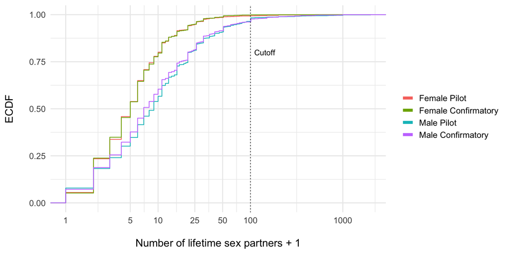

Figure 2: Cumulative distribution of the number of sexual partners, by sex. Participants who reported 100 or more partners were removed from the analysis. The x-axis is on a log scale, so 1 was added to the number of partners to prevent removal of individuals with 0 sexual partners (only for this Figure and not for any analyses).

### Descriptive statistics

The mean age was 38 years. Sexual dimorphism—the ratio of male mean:female mean—was evident in an 8% higher value for male height and a 16% higher value for weight; females, however, had a 1% higher BMI than males on average. There was a much larger degree of male-biased dimorphism in grip strength (57%). Hemoglobin was 14% higher in males than females while white blood cell count was 3% higher in women. See Table S2 for weighted means, standard deviations, and standardized mean differences of all variables for men and women.

### Coefficients of sex-specific grip strength, and sex-specific grip strength x sex interaction

There were also clear sex differences in the effects of sex-specific grip strength on two mating success outcomes—partnered status and lifetime sexual partners—with smaller effects for women compared to men, as predicted by the sexual selection hypothesis. There was also a persistent negative association of lifetime sexual partners on the probability of partnered status in all models of this outcome (Figure S1). Finally there was no evidence for a sex difference in the effects of sex-specific grip strength on past-year sexual partners or age at first sex, contrary to the sexual selection hypothesis. See the right column of Figure 3.

For a plot of all coefficients, see Figure 4.

### Immune costs of strength

Previous research found that higher musculature was associated with decreased investment in innate immunity. We developed two models of immune investment in white blood cell count (Figure 6). In our version of the Lassek and Gaulin model, grip strength was a significant negative predictor of WBCC for both men and women (there was no significant interaction of sex and grip strength) controlling for age and BMI. In the expanded model with additional controls, including the substitution of height and weight for BMI, grip strength was no longer significant, albeit with a coefficient that was very similar to the replication model.

### Models of energy and protein intake

Finally, we tested whether grip strength was related to increased energy or protein intake (Figure 7). We found that grip strength was a significant, positive predictor of both energy and protein intake controlling for sex. In the expanded models with additional controls, grip strength was no longer a significant predictor of energy intake but remained a significant predictor of protein intake.

## Pilot Results Discussion

The sexual selection hypothesis predicts that the effect of strength on mating success will be greater for men than for women, and this prediction was exceptionally well-supported for partnered status and lifetime sexual partners. In humans, biological fitness depends critically on extensive investment in offspring which typically takes place in long-term partnerships. We therefore propose that the sexual selection hypothesis for the sexual dimorphism in physical formidability applies to long-term partnerships (proxied by our partnered variable), as well as short-term matings (proxied by partner numbers). Thus, our pilot study supports the hypothesis that muscularity increases both short- and long-term mating success for men more than it does for women. Lifetime sexual partners was also a negative predictor of partnered status (Figure S1), suggesting a tradeoff in pursuing these two reproductive strategies.

The effect of sex-specific grip strength on age at first sex was not significant in our socioeconomic model probably because it is confounded with ethnicity. Specifically, Asian Americans had a markedly lower grip strength compared to the other ethnic groups, and a later age at first sex. In addition, participants, whose grip strength was measured at the time of the study when they were adults, are reporting on an event that happened an average of 22 years in the past when most were adolescents and their grip strength had not yet reached its adult value. For these reasons, we do not predict an effect of sex-specific grip strength on age at first sex after controlling for ethnicity.

Sex-specific grip strength was also not significantly associated with the number of sexual partners in the past year, despite controlling for partnered status, which was a significant negative predictor. Approximately 60% of the sample was partnered (Table S2), however, and stronger individuals, especially men, were more likely to be partnered. The pool of unpartnered individuals who might pursue multiple mating opportunities was therefore smaller and skewed toward lower grip strength individuals, and variation in this outcome over the relatively short time period (1 year) was low. Nevertheless, the non-significant sex-specific grip strength coefficients were all positive, raising the possibility that a higher powered study might successfully detect a positive effect of sex-specific grip strength on number of partners in the past year.

# Stage 2 Confirmatory Study

In a large, nationally representative US sample, we predict that formidability will be significantly positively associated with mating success as indexed by partnered status and lifetime number of sexual partners, but not past-year number of partners, nor age at first sex after controlling for ethnicity. We also predict a significant interaction with sex such that sex-specific grip strength will be a stronger predictor of male than female partnered status and lifetime number of sexual partners, but not number of past-year sexual partners nor age at first sex. We also predict that there will be a significant negative association between formidability and immune function. Finally, we predict that formidability will be positively associated with dietary protein intake for both males and females.

We indicate our predictions for the results of the confirmatory tests, specifically, our predictions for significant coefficients of grip strength and of the interaction between sex and grip strength, in Table 1. We indicate for each outcome whether we predict a significant positive, negative, or no effect of these variables across our control models.

| Outcome | Grip Strength Coefficient | Grip Strength X Sex Coefficient |
| --- | --- | --- |
| Partnered status | + | - |
| Lifetime partners | + | - |
| Past-year partners | ns | ns |
| Age at first sex | ns | ns |
| Immunity | - | ns |
| Energy | ns |  |
| Protein | + |  |

Table 1: Predictions. A plus sign (+) indicates a predicted significantly positive coefficient in all models of grip strength; a negative sign (-) indicates a predicted significantly negative coefficient in all such models; ns indicates a predicted non-significant coefficient in any such model; and a blank indicates not relevant.

## Power

Effects in replication studies are often smaller than in the original studies (Klein et al., 2018). We therefore used simulations to estimate our power to detect grip strength and $grip\ strength\times sex$ coefficients that are 25-100% as large as the ones observed in our pilot study for partnered and lifetime sexual partners, with a sample size equal to that in our unobserved data. We have high power to detect effects at least 75% as large as the ones observed in our pilot study, and reasonable power to detect those that are at least 50% as large (Table S1).

## Confirmatory Study Methods

Our methods and models remained identical to those reported in the pilot study, other than the deviations reported below, using unobserved data from the 2013-2014 NHANES collection cycle. After testing and reporting our predictions using the unobserved data, we fit our models on the combined data (2011-2014), and conduct other post hoc analyses.

## Deviations from Stage 1 methods

Model specification and R code for three of our four mating success outcome variables remain identical to those used in the Stage 1 pilot study. However, although the Poisson regression model of lifetime sexual partners in the pilot study included age as a control, it is more appropriate to instead include age as an exposure variable (an offset) in the model, an adjustment we apply to both the pilot and confirmatory models. We also treat this exposure as years since sexual maturity (defined as age - 12 years because 95% of participants first had sex at age 12 or older). The changes in the grip strength and $grip\ strength\times sex$ coefficients and their standard errors from this change in model specification are minimal (see Figure S6).

## Confirmatory Study Results

### Descriptive statistics

Sample characteristics were similar in the confirmatory dataset to those in the pilot dataset. See Table S19 for weighted means, standard deviations, and standardized mean differences of all variables for men and women.

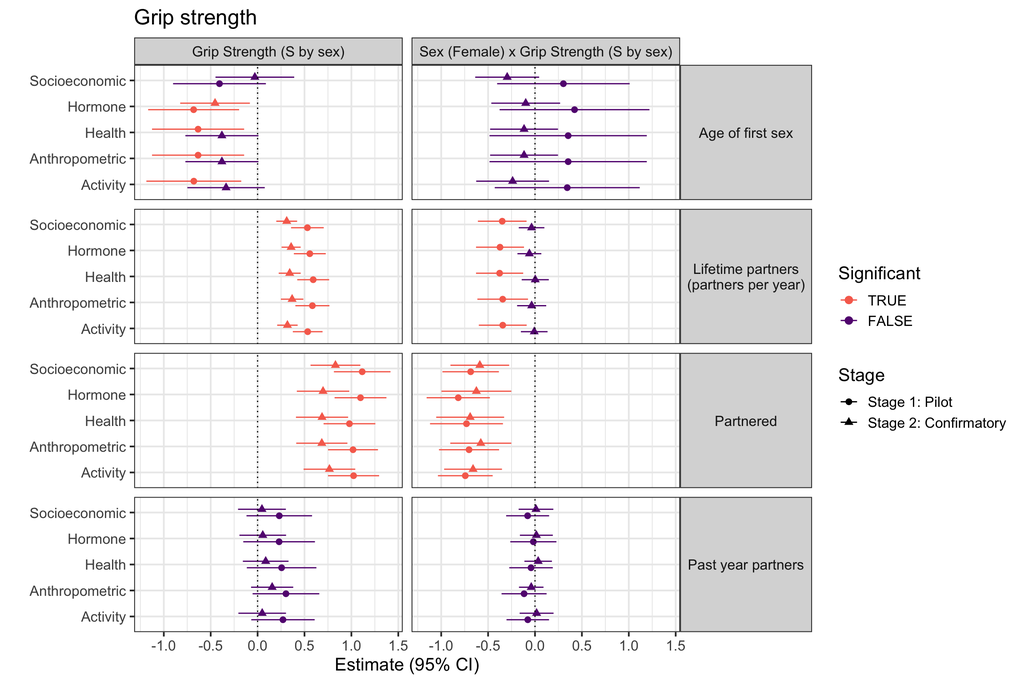

Figure 3: Coefficients of sex-specific grip strength, and sex-specific grip strength X sex interaction for our four mating success outcomes and our five sets of potential confounding variables. Partnered coefficients are from logistic regressions, partner number coefficients are from quasi-Poisson glm regressions, and age at first sex coefficients are from Gaussian glm regressions. Bars are 95% CIs. For the full regression tables, see the SI.

### Relationship between sex-specific grip strength and four measures of mating success

Unlike findings from the pilot study, a clear sex difference in the effects of sex-specific grip strength only emerged for one mating success outcome—partnered status—with smaller effects for women compared to men, as predicted by the sexual selection hypothesis. The interaction between sex and sex-specific grip strength on lifetime number of sexual partners was not replicated in the confirmatory data. Finally there was no evidence for a sex difference in the effects of sex-specific grip strength on past-year number of partners or age at first sex, contrary to the sexual selection hypothesis. See Figure 3 for coefficients of sex-specific grip strength and $grip\ strength\times sex$ interaction for each proxy of mating success in both pilot and confirmatory data. See Figure 4 for coefficients of potential confounds in each model in the confirmatory data. For effects plots of the effect of sex-specific grip strength on each mating outcome in pilot and confirmatory studies (on the response scale), see Figure 5.

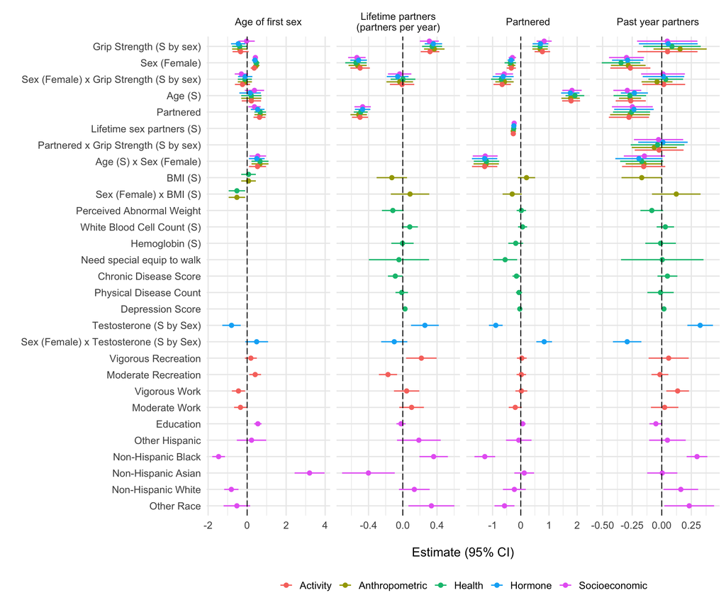

Figure 4: Stage 2 Confirmatory study coefficients from all models of the four mating success outcomes and the five sets of potential confounding variables. Partnered coefficients are from logistic regressions, partner number coefficients are from quasi-Poisson glm regressions, and age at first sex coefficients are from Gaussian glm regressions. Mexican Amercians are the base level for the ethnicity control variable. Bars are 95% CIs. For the full regression tables, see the SI.

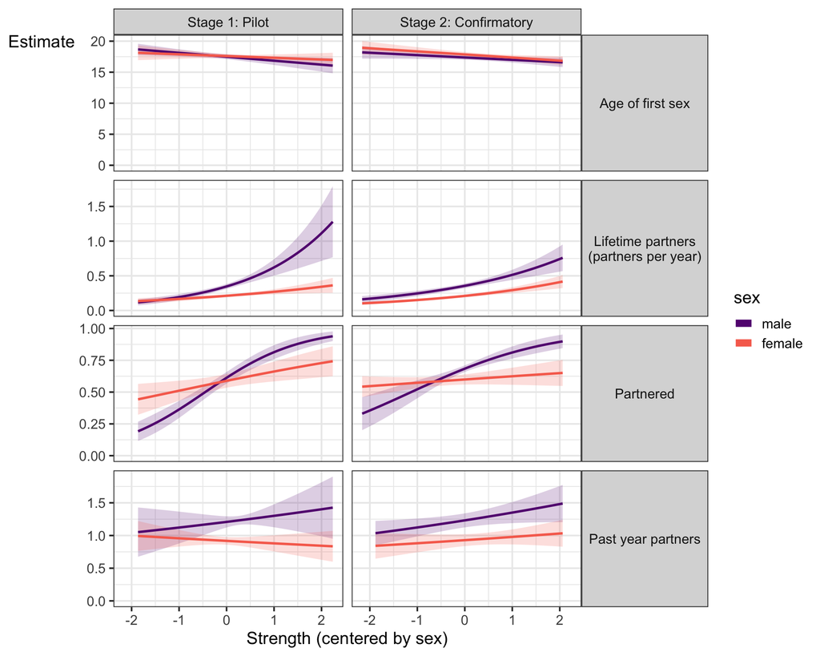

Figure 5: Effects of sex-specific grip strength on mating outcomes, by sex. Grip strength is centered and scaled by 2 SD, separately for each sex (almost all participants therefore fall between -1 and 1). Plots are based on the anthropometric control models, with control variables held at their mean values. Lifetime partners is modeled as the rate of new partners per year since reaching sexual maturity (age 12). Outcomes are on the response scale.

### Immune costs of strength

In our confirmatory data we found no significant effects of grip strength or a $grip\ strength\times sex$ interaction on WBCC in either our version of the Lassek and Gaulin model, or the expanded controls model (Figure 6).

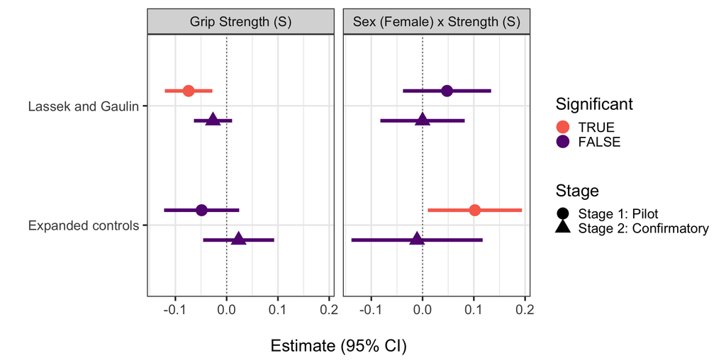

Figure 6: Coefficient plot of predictors of immune investment (WBCC) from generalized linear models. Variables labeled (S) have been centered at the mean and standardized by 2 SD. Bars are 95% CIs.

### Dietary costs of strength

Finally, we tested whether strength was related to increased energy or protein intake. We found that grip strength was a significant, positive predictor of both energy and protein intake controlling for sex. In the expanded models with additional controls, grip strength remained a significant predictor of energy and protein intake in our confirmatory analysis. See Figure 7.

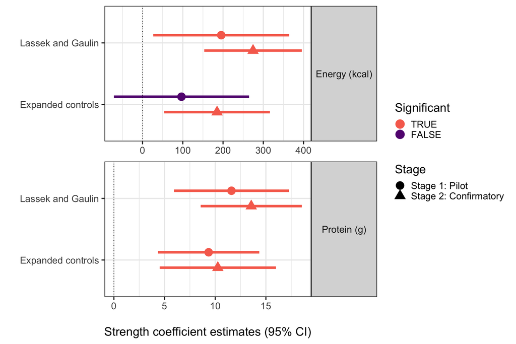

## Predictions and Results

| Outcome | Grip strength coefficient Prediction | Grip strength coefficient Supported | Grip strength X sex coefficient Prediction | Grip strength X sex coefficient Supported |
| --- | --- | --- | --- | --- |
| Partnered status | + | ✓ | - | ✓ |
| Lifetime partners | + | ✓ | - | ❌ |
| Past-year partners | ns | ✓ | ns | ✓ |
| Age at first sex | ns | ✓ | ns | ✓ |
| Immunity | - | ❌* | ns | ✓ |
| Energy | ns | ❌* |  |  |
| Protein | + | ✓ |  |  |

Table 2: Predictions. A plus sign (+) indicates a predicted significantly positive coefficient in all models of grip strength; a negative sign (-) indicates a predicted significantly negative coefficient in all such models; ns indicates a predicted non-significant coefficient in any such model; and a blank indicates not relevant. ✓: Supported in confirmatory study. ❌: Not supported in confirmatory study. *The posthoc results found a significant negative association between lean mass and immunity, and a positive association grip strength and lean mass with energy.

# Post Hoc Analyses

After we download the data for this study, Dual-Energy X-ray Absorptiometry (DXA) data were published for these series. DXA data provide alternatives to grip strength for assessing muscle mass, and include the lean masses (i.e., fat-free mass, optionally including or excluding bone mineral content) in grams of each arm and leg, the trunk, and total body. Total body lean mass is similar to the bioelectrical impedance analysis fat-free mass variable used by Lassek & Gaulin (2009). For reviews of DXA measurements of body composition, see Shepherd, Ng, Sommer, & Heymsfield (2017) and Messina et al. (2020). For details of the NHANES DXA measurements, see NHANES (2023). In addition to our grip strength models, we also fit our models exactly as specified in stage 1 except substituting four DXA lean masses for grip strength (all masses excluded bone mineral content). Specifically, we computed arm lean mass as the sum of left and right arm lean masses, and leg lean mass as the sum of left and right leg lean masses. We then fit our models using arm, leg, trunk, and total lean masses, each standardized by sex as described earlier for grip strength.

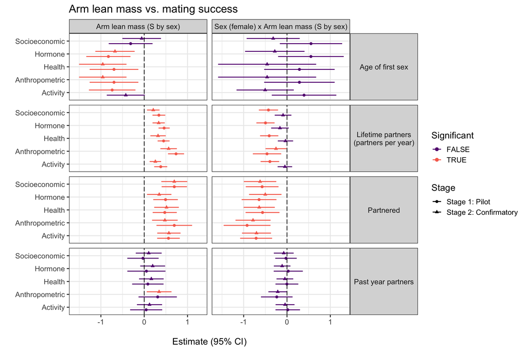

Figure 8: Coefficients of sex-specific arm lean mass, and lean mass X sex interaction for our four mating success outcomes and our five sets of potential confounding variables. Partnered coefficients are from logistic regressions, partner number coefficients are from quasi-Poisson glm regressions, and age at first sex coefficients are from Gaussian glm regressions. Bars are 95% CIs.

Unlike grip strength, arm, leg, and total (but not trunk) lean masses were all negatively associated with WBCC. We found that all lean masses were significant, positive predictors of both energy and protein intake controlling for sex. In the expanded models with additional controls, all lean masses remained significant predictors of energy and protein intake. See Figure S10 - Figure S13.

Finally, we fit our grip strength models on the combined data (2011-2014). Results qualitatively correspond to those in the pilot study, which is not surprising because our models were developed on the pilot data. See Figure S15 - Figure S18.

# Discussion

The purpose of this study was to replicate, as closely as possible, the Lassek & Gaulin (2009) study with new data that used combined grip strength as a proxy for upper body strength, as well as the lean masses of arms, legs, trunk, and total body. Unlike Lassek & Gaulin (2009), we included women to test if the associations of upper body strength and lean masses with mating success were greater for men than women, as predicted by the sexual selection hypothesis. We also included numerous additional control variables, and used a registered report format with pre-specified models developed using pilot data in Stage 1 and then fit on held-out data in Stage 2.

In the Stage 2 Confirmatory Study, we found consistent support for a positive relationship between both sex-specific combined grip strength and sex-specific arm lean mass, and two measures of mating success: being currently partnered, and lifetime number of sexual partners for men, controlling for numerous possible confounds. We found no consistent association between either sex-specific combined grip strength or any sex-specific lean masses and age at first sex or number of past-year sexual partners.

We also tested for interactions between sex and strength on these mating success outcomes. Across both pilot and confirmatory analyses, we found a consistent interaction between sex and sex-specific grip strength on partnered status, such that sex-specific grip strength was a better predictor of males’ partnered status than females. Although in the pilot analysis we did see evidence of an interaction between sex and sex-specific grip strength on the outcome lifetime number of sexual partners, such that sex-specific grip strength was a better predictor of males’ lifetime sexual partners, this effect was not significant in the confirmatory analysis.

The lack of a sex difference in the significant positive effect of sex-specific grip strength on short term mating success (proxied by number of lifetime sexual partners) is puzzling. Men have greater strength than women and their average partner numbers are higher. Still, women with higher grip strength and arm lean mass unexpectedly reported more lifetime sexual partners on average than women with lower grip strength or arm lean mass, even after controlling for a host of potential confounds. A meta-analysis of 77 species, including humans and 7 other mammal species, found a positive Bateman gradient for females, i.e., a positive correlation between mating success and reproductive success, although authors and commentators both caution that correlation is not causation (Fromonteil, Marie-Orleach, Winkler, & Janicke, 2023; Kokko & Jennions, 2023).

Still, it is not clear why women’s strength would be positively associated with partner numbers. It could be that there was selection for more formidable men to prefer more partner variety, and stronger women have a similar preference as a byproduct of selection on men. It could be that there is assortative mating on strength: if stronger men are motivated to switch partners more frequently, their (stronger) mates would also likely have more mates. It might be that stronger women require less male investment, or can take more physical risks, and so instead benefit from greater partner numbers through, e.g. genetic bet-hedging, forging relationships with multiple males, ability to conduct a more extensive search for a high quality long term mate, or through avoiding or leaving costly long-term partnerships. It might be the case that there are some sex-specific confounds that we failed to control for, or that our models are otherwise misspecified. There also might be reverse causation, e.g., women who are interested in greater partner variety keep in better shape. Greater partner numbers might indicate mating failures rather than mating successes for males or females, although why strength would be associated with mating failures is not clear. Since a sex difference was significant in the Pilot Study (2011-12), but not in the Confirmatory Study (2013-14), it is possible that cultural changes influencing sexual behavior occurred between the data collection cycles. The sexual sexual hypothesis also might be wrong. Or these results might simply be noise.

## Limitations

Our registered report had one aim: to test the prediction from the sexual selection hypothesis that the effect of upper body strength on reproductive success is significantly positive for males and significantly less so for females. Our aim was not to test all possible byproduct hypotheses, nor was it possible to do so. We were unable to control for in-utero testosterone exposure, or other conditions such as Polycystic Ovarian Syndrome (PCOS) that might influence the relationship between grip strength and our measures of mating success. Likewise, NHANES does not collect data on sociosexuality. As described in our methods, in industrialized populations like the U.S., widespread access to contraceptives uncouples reproductive success from mating behavior for both men and women. Measures of mating success, including partnered status, number of sexual partners, and age at first sexual intercourse, are used as proxies as they are assumed to have been strongly correlated with reproductive success under ancestral conditions (Pérusse, 1993). In addition, in confirmatory analyses of mating outcomes (but not immune, energy, or protein outcomes) we removed 68 participants with 100 or more lifetime sexual partners (1.55%) on the grounds that these might involve evolutionarily novel patterns of behavior that would not conform to predictions of the sexual selection hypothesis. Ideally, however, analyses would account for the full range of variation in sexual behavior (in a post hoc analysis, we refit our models on the combined pilot and confirmatory data, and all results were very similar to those we report; see the SI). Finally, all pilot results were obtained after considerable exploratory analysis, with a high risk of overfitting the data, and therefore our confirmatory results were critical to testing our predictions. However, our confirmatory results were based on generalized linear models, but there might be important non-linear relationships that would alter interpretations.

# Conclusion

Our results most strongly support the importance of upper body strength to male long-term mating success, which is the basis of biparental care in human reproduction (Bribiescas, Ellison, & Gray, 2012; Gettler, Boyette, & Rosenbaum, 2020). This benefit would compensate for the energy, protein, and immune costs associated with strength in our confirmatory results and lean masses in our post hoc results. Across evolutionary time, fitness for both men and women was heavily dependent on successfully obtaining long-term partners, thereby reaping the efficiency benefits of a sexual division of labor (Quinlan, 2008; Quinlan & Quinlan, 2007). More specifically, human children require provisioning for an extended period (Davison & Gurven, 2022; Davison & Gurven, 2021; Kaplan et al., 2000), and paternal care is an important predictor of child outcomes (Starkweather et al., 2021; Winking, Gurven, & Kaplan, 2011). Thus, our study underscores that the sexual selection hypothesis for the relationship between strength and mating success should include long-term mating in addition to numbers of sexual partners.

Moreover, in addition to formidability, which is important in male-male competition for short and long-term partners, upper body strength indexes productivity. Specifically, strength in forearm and shoulder is critical for effective use of projectile hunting technology such as the bow and arrow (Ertan, Kentel, Tümer, & Korkusuz, 2003) and javelin (Kim, Lee, Shin, Kim, & Moon, 2014). Indeed, upper body strength predicted both hunting reputation and reproductive success in Hadza men (Apicella, 2014). The similarities in our results between grip strength and arm lean mass as predictors further supports the importance of upper body strength in particular. Therefore, our results could support an evolved female preference for productivity, i.e., the greater ability over human evolution of stronger men to provision offspring through big-game hunting (Apicella, 2014; Kaplan et al., 2000), although an evolved preference for long-term partners who can confer protection from predators or other men is possible too (Kelly, 2005; Willems & Schaik, 2017).

# Acknowledgements

We thank the Editor and two anonymous reviewers for their numerous helpful comments and suggestions. We thank Michael Barlev for pointing us to the DXA data.

# Data availability

All data and code are available here: https://github.com/grasshoppermouse/strengthmating

# Supplementary Information

## Power

| Scale | Partnered strength | Partnered sex X strength | Lifetime partners strength | Lifetime partners sex X strength | Past-year partners strength | Past-year partners sex X strength |
| --- | --- | --- | --- | --- | --- | --- |
| 0.25 | 0.76 | 0.27 | 0.89 | 0.22 | 0.18 | 0.055 |
| 0.50 | 1.00 | 0.75 | 1.00 | 0.64 | 0.58 | 0.101 |
| 0.75 | 1.00 | 0.98 | 1.00 | 0.95 | 0.89 | 0.188 |
| 1.00 | 1.00 | 1.00 | 1.00 | 1.00 | 0.99 | 0.274 |

Table S1: Power to detect grip strength and sex X grip strength coefficients that range from 25% to 100% of the size seen in the pilot study, based on models with anthropometric controls. **Scale**: the proportion of the effect seen in the pilot study. All other values are power (1-B). Values rounded to two significant digits. Bold: power > 0.80.

## Stage 1: Pilot study

### Descriptive statistics

| **Variable** | **Male** **N** | **Male** **Mean (SD)**<sup>1</sup> | **Female** **N** | **Female** **Mean (SD)**<sup>1</sup> | **Sexual Dimorphism** **Ratio** | **Sexual Dimorphism** **SMD**<sup>2</sup> |
| --- | --- | --- | --- | --- | --- | --- |
| Age (Years) | 2,026 | 38.70 (12.74) | 2,103 | 39.22 (12.31) | 0.99 | -0.04 |
| Age at first sex (years) | 1,588 | 17.26 (3.90) | 1,587 | 17.46 (3.47) | 0.99 | -0.05 |
| Lifetime number of sexual partners | 1,684 | 12.03 (15.10) | 1,654 | 7.31 (8.88) | 1.65 | 0.38 |
| Past year number of sexual partners | 1,642 | 1.40 (2.30) | 1,612 | 1.02 (1.02) | 1.37 | 0.21 |
| Combined Grip Strength (kg) | 1,781 | 93.01 (17.20) | 1,767 | 59.13 (10.38) | 1.57 | 2.38 |
| Arm lean mass (g) | 1,577 | 7,816.39 (1,479.63) | 1,415 | 4,475.34 (967.84) | 1.75 | 2.67 |
| Leg lean mass (g) | 1,550 | 19,523.09 (3,514.83) | 1,430 | 14,075.30 (3,287.84) | 1.39 | 1.60 |
| Trunk lean mass (g) | 1,584 | 30,150.87 (5,435.46) | 1,405 | 22,417.60 (4,513.77) | 1.34 | 1.55 |
| Total lean mass (g) | 1,528 | 60,705.43 (9,867.31) | 1,406 | 43,699.87 (8,540.41) | 1.39 | 1.84 |
| Body mass index (kg/m^2) | 1,930 | 28.38 (6.06) | 2,000 | 28.80 (7.58) | 0.99 | -0.06 |
| Height (cm) | 1,932 | 176.24 (7.61) | 2,003 | 162.83 (7.23) | 1.08 | 1.81 |
| Weight (kg) | 1,931 | 88.28 (20.30) | 2,001 | 76.35 (20.65) | 1.16 | 0.58 |
| White blood cell count (1000 cells/µL) | 1,846 | 6.93 (2.02) | 1,934 | 7.19 (2.10) | 0.96 | -0.13 |
| Hemoglobin (g/dL) | 1,846 | 15.11 (1.08) | 1,934 | 13.27 (1.15) | 1.14 | 1.65 |
| Testosterone (ng/dL) | 1,783 | 408.40 (169.76) | 1,855 | 25.69 (23.31) | 15.90 | 3.16 |
| Chronic Disease Score (0-6) | 1,858 | 0.40 (0.66) | 1,947 | 0.54 (0.82) | 0.74 | -0.19 |
| Disease Impairment Score (0-5) | 2,026 | 0.20 (0.68) | 2,102 | 0.27 (0.83) | 0.74 | -0.09 |
| Depression Score (0-27) | 1,731 | 2.72 (4.11) | 1,698 | 3.48 (4.54) | 0.78 | -0.18 |
| Dietary energy intake (kcals) | 1,553 | 2,544.97 (844.12) | 1,678 | 1,854.39 (619.96) | 1.37 | 0.93 |
| Dietary protein intake (grams) | 1,553 | 99.55 (36.88) | 1,678 | 70.23 (25.65) | 1.42 | 0.92 |
| Food Insecurity Rating (1-4) | 2,019 | 1.54 (0.96) | 2,094 | 1.58 (0.98) | 0.97 | -0.04 |
| Total MET | 2,016 | 86.07 (113.53) | 2,099 | 42.19 (69.35) | 2.04 | 0.47 |
| Partnered | 1,869 | 1,091 (60%) | 1,955 | 1,093 (62%) |  |  |
| Education |  |  |  |  |  |  |
| 1 | 2,026 | 136 (5.0%) | 2,103 | 122 (4.1%) |  |  |
| 2 | 2,026 | 328 (13%) | 2,103 | 293 (10%) |  |  |
| 3 | 2,026 | 471 (22%) | 2,103 | 398 (18%) |  |  |
| 4 | 2,026 | 606 (31%) | 2,103 | 705 (35%) |  |  |
| 5 | 2,026 | 485 (29%) | 2,103 | 585 (33%) |  |  |
| Race and Ethnicity |  |  |  |  |  |  |
| MexicanAmerican | 2,026 | 251 (10%) | 2,103 | 226 (9.0%) |  |  |
| OtherHispanic | 2,026 | 190 (7.2%) | 2,103 | 235 (7.5%) |  |  |
| NonHispanicWhite | 2,026 | 695 (63%) | 2,103 | 670 (61%) |  |  |
| NonHispanicBlack | 2,026 | 501 (11%) | 2,103 | 576 (14%) |  |  |
| NonHispanicAsian | 2,026 | 316 (5.3%) | 2,103 | 337 (5.9%) |  |  |
| OtherRace | 2,026 | 73 (2.7%) | 2,103 | 59 (2.5%) |  |  |
| Perceived abnormal weight | 2,018 | 963 (51%) | 2,099 | 1,299 (63%) |  |  |
| Special equipment needed to walk | 1,869 | 81 (2.9%) | 1,956 | 112 (4.6%) |  |  |
| Work involves vigorous activity | 2,026 | 525 (29%) | 2,103 | 206 (11%) |  |  |
| Work involves moderate activity | 2,026 | 776 (42%) | 2,103 | 591 (32%) |  |  |
| Recreation involves vigorous activity | 2,026 | 762 (37%) | 2,103 | 464 (25%) |  |  |
| Recreation involves moderate activity | 2,026 | 906 (48%) | 2,103 | 939 (50%) |  |  |

<sup>1</sup> Weighted means and standard deviations shown for continuous variables, unweighted n (%) for categorical variables  
<sup>2</sup> Standardized Mean Difference

Table S2: Pilot: Descriptive statistics and sex differences for participants ages 18-60 using population weights

### The negative association of lifetime number of sexual partners with partnered status

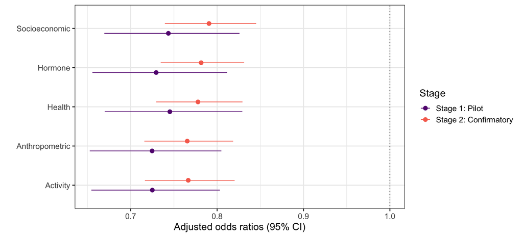

Figure S1: The adjusted odds ratios of lifetime number of sexual partners on partnered status. In these models, lifetime partners was divided by 10, the interquartile range.

### Marginal effects

| sex | partnered | estimate |
| --- | --- | --- |
| male |  | 0.18 |
| female |  | 0.069 |
| male | FALSE | 0.50 |
| male | TRUE | 0.30 |
| female | FALSE | 0.10 |
| female | TRUE | 0.058 |
| male | FALSE | 0.58 |
| male | TRUE | 0.091 |
| female | FALSE | 0.24 |
| female | TRUE | -0.037 |
| male |  | -0.63 |
| female |  | -0.28 |

Table S3: The average marginal effect of a 2 standard deviation increase in grip strength on each mating outcome, by sex and partnered status, for the models with anthropometric controls.

### Correlation matrices of study variables

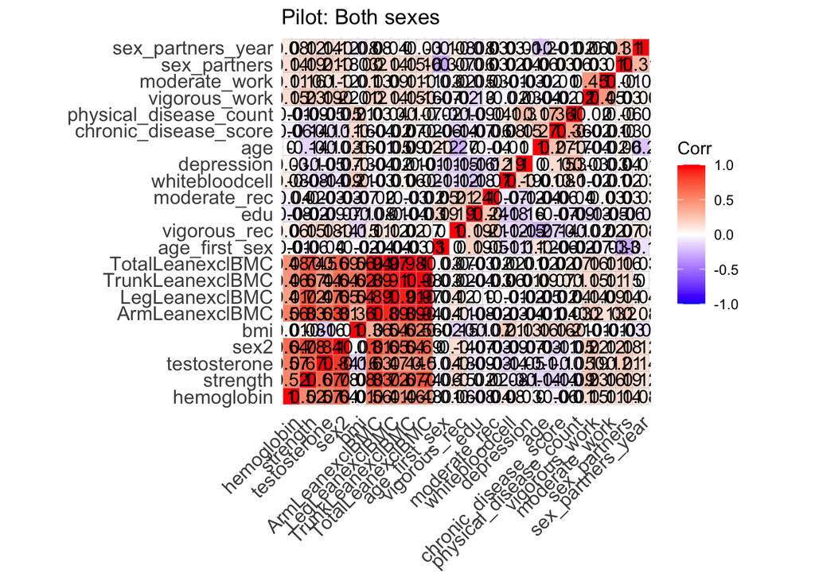

Figure S2: Correlation matrix of study variables (both sexes). Rows and columns ordered by hierarchical clustering.

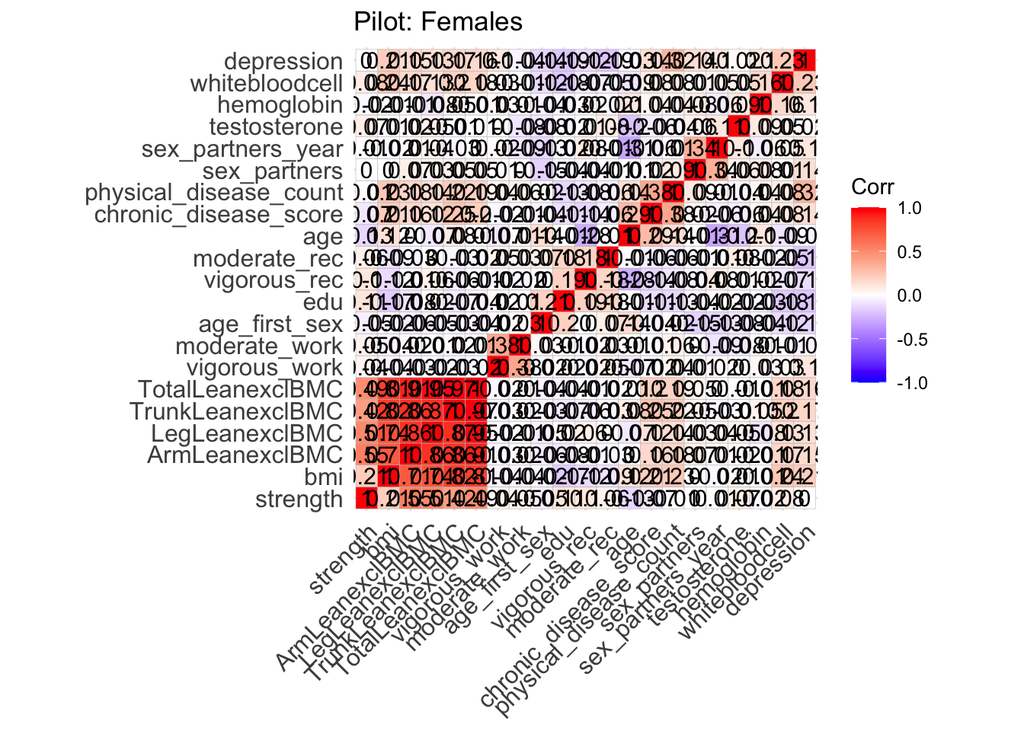

Figure S3: Correlation matrix of study variables for females only. Rows and columns ordered by hierarchical clustering.

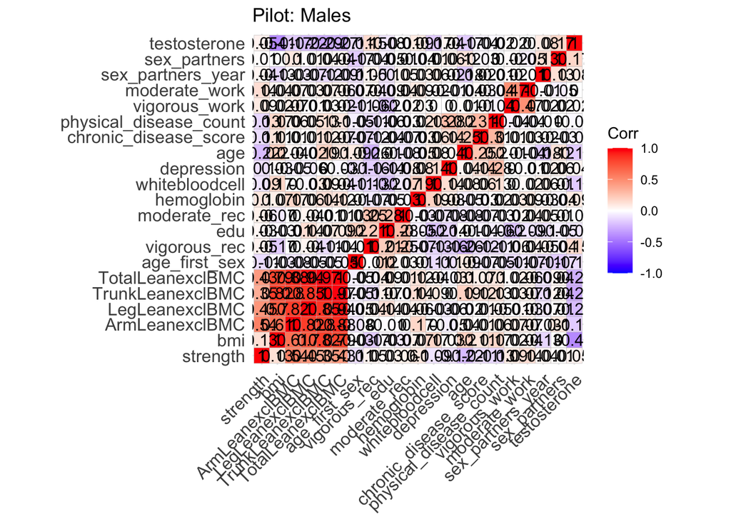

Figure S4: Correlation matrix of study variables for males only. Rows and columns ordered by hierarchical clustering.

### Regression tables (Pilot study)

|  | Anthropometric | Socioeconomic | Health | Hormone | Activity |
| --- | --- | --- | --- | --- | --- |
| (Intercept) | 17.154 | 15.688 | 17.154 | 17.170 | 17.092 |
|  | (0.169) | (0.288) | (0.169) | (0.170) | (0.206) |
| Age (S) | 0.757 | 0.896 | 0.757 | 0.592 | 0.703 |
|  | (0.235) | (0.253) | (0.235) | (0.247) | (0.245) |
| Sex (Female) | 0.107 | 0.043 | 0.107 | 0.092 | 0.003 |
|  | (0.132) | (0.129) | (0.132) | (0.128) | (0.146) |
| Grip Strength (S by sex) | -0.635 | -0.406 | -0.635 | -0.682 | -0.680 |
|  | (0.251) | (0.252) | (0.251) | (0.247) | (0.258) |
| Partnered | 0.326 | 0.073 | 0.326 | 0.309 | 0.310 |
|  | (0.195) | (0.172) | (0.195) | (0.194) | (0.188) |
| BMI (S) | -0.459 |  | -0.459 |  |  |
|  | (0.360) |  | (0.360) |  |  |
| Age (S) x Sex (Female) | 0.253 | 0.267 | 0.253 | 0.395 | 0.289 |
|  | (0.283) | (0.273) | (0.283) | (0.296) | (0.292) |
| Sex (Female) x Grip Strength (S by sex) | 0.354 | 0.303 | 0.354 | 0.422 | 0.344 |
|  | (0.428) | (0.360) | (0.428) | (0.408) | (0.394) |
| Sex (Female) x BMI (S) | 0.363 |  | 0.363 |  |  |
|  | (0.432) |  | (0.432) |  |  |
| Other Hispanic |  | -0.732 |  |  |  |
|  |  | (0.300) |  |  |  |
| Non-Hispanic White |  | -1.098 |  |  |  |
|  |  | (0.218) |  |  |  |
| Non-Hispanic Black |  | -1.548 |  |  |  |
|  |  | (0.236) |  |  |  |
| Non-Hispanic Asian |  | 2.982 |  |  |  |
|  |  | (0.300) |  |  |  |
| Other Race |  | -1.403 |  |  |  |
|  |  | (0.311) |  |  |  |
| Education |  | 0.649 |  |  |  |
|  |  | (0.080) |  |  |  |
| Testosterone (S by Sex) |  |  |  | -0.511 |  |
|  |  |  |  | (0.220) |  |
| Sex (Female) x Testosterone (S by Sex) |  |  |  | 0.417 |  |
|  |  |  |  | (0.273) |  |
| Vigorous Recreation |  |  |  |  | 0.086 |
|  |  |  |  |  | (0.224) |
| Moderate Recreation |  |  |  |  | 0.381 |
|  |  |  |  |  | (0.183) |
| Vigorous Work |  |  |  |  | -0.596 |
|  |  |  |  |  | (0.252) |
| Moderate Work |  |  |  |  | 0.093 |
|  |  |  |  |  | (0.241) |
| Num.Obs. | 2732 | 2748 | 2732 | 2582 | 2748 |

Table S4: Age of first sex ( GAUSSIAN ) regression model coefficients

|  | Lassek and Gaulin | Expanded controls |
| --- | --- | --- |
| (Intercept) | 2470.672 | 2507.831 |
|  | (41.667) | (52.802) |
| Age (S) | -22.823 | -29.396 |
|  | (53.336) | (53.160) |
| Total MET (S) | 82.553 | 89.246 |
|  | (48.889) | (48.661) |
| Grip Strength (S) | 195.455 | 96.690 |
|  | (86.190) | (85.667) |
| BMI (S) | -12.726 |  |
|  | (49.370) |  |
| Sex (Female) | -535.954 | -479.619 |
|  | (79.960) | (82.064) |
| Weight (S) |  | -1.636 |
|  |  | (52.691) |
| Height (S) |  | 205.322 |
|  |  | (45.284) |
| White Blood Cell Count (S) |  | 68.110 |
|  |  | (37.984) |
| Food Insecurity |  | -41.904 |
|  |  | (20.795) |
| Num.Obs. | 2977 | 2883 |

Table S5: Energy (kcal) ( GAUSSIAN ) regression model coefficients

|  | Lassek and Gaulin | Expanded controls |
| --- | --- | --- |
| (Intercept) | 1.962 | 1.931 |
|  | (0.018) | (0.021) |
| Age (S) | 0.012 | 0.028 |
|  | (0.017) | (0.027) |
| Sex (Female) | -0.002 | 0.007 |
|  | (0.029) | (0.030) |
| Grip Strength (S) | -0.074 | -0.049 |
|  | (0.024) | (0.037) |
| BMI (S) | 0.131 |  |
|  | (0.014) |  |
| Age (S) x Sex (Female) | -0.097 | -0.096 |
|  | (0.022) | (0.041) |
| Sex (Female) x Strength (S) | 0.048 | 0.102 |
|  | (0.044) | (0.047) |
| Weight (S) |  | 0.105 |
|  |  | (0.017) |
| Height (S) |  | -0.122 |
|  |  | (0.028) |
| Testosterone (S by Sex) |  | -0.073 |
|  |  | (0.018) |
| Food Insecurity |  | 0.017 |
|  |  | (0.008) |
| Average calories per day (S) |  | 0.023 |
|  |  | (0.015) |
| Total MET (S) |  | 0.033 |
|  |  | (0.020) |
| Depression Score |  | 0.004 |
|  |  | (0.001) |
| Sex (Female) x Testosterone (S by Sex) |  | 0.123 |
|  |  | (0.013) |
| Num.Obs. | 3418 | 2620 |

Table S6: Immunity ( QUASIPOISSON ) regression model coefficients

|  | Anthropometric | Socioeconomic | Health | Hormone | Activity |
| --- | --- | --- | --- | --- | --- |
| (Intercept) | -0.484 | -0.510 | -0.433 | -0.499 | -0.587 |
|  | (0.067) | (0.087) | (0.101) | (0.064) | (0.072) |
| Grip Strength (S by sex) | 0.584 | 0.531 | 0.593 | 0.557 | 0.534 |
|  | (0.093) | (0.089) | (0.087) | (0.087) | (0.081) |
| Sex (Female) | -0.492 | -0.505 | -0.515 | -0.493 | -0.477 |
|  | (0.053) | (0.055) | (0.083) | (0.056) | (0.057) |
| Partnered | -0.570 | -0.539 | -0.531 | -0.548 | -0.566 |
|  | (0.078) | (0.076) | (0.085) | (0.073) | (0.075) |
| BMI (S) | -0.266 |  |  |  |  |
|  | (0.111) |  |  |  |  |
| Sex (Female) x Grip Strength (S by sex) | -0.344 | -0.349 | -0.377 | -0.373 | -0.344 |
|  | (0.138) | (0.132) | (0.128) | (0.130) | (0.130) |
| Sex (Female) x BMI (S) | 0.002 |  |  |  |  |
|  | (0.117) |  |  |  |  |
| Education |  | -0.019 |  |  |  |
|  |  | (0.024) |  |  |  |
| Other Hispanic |  | 0.243 |  |  |  |
|  |  | (0.096) |  |  |  |
| Non-Hispanic White |  | 0.059 |  |  |  |
|  |  | (0.078) |  |  |  |
| Non-Hispanic Black |  | 0.213 |  |  |  |
|  |  | (0.097) |  |  |  |
| Non-Hispanic Asian |  | -0.398 |  |  |  |
|  |  | (0.109) |  |  |  |
| Other Race |  | 0.343 |  |  |  |
|  |  | (0.166) |  |  |  |
| Perceived Abnormal Weight |  |  | -0.193 |  |  |
|  |  |  | (0.059) |  |  |
| White Blood Cell Count (S) |  |  | 0.090 |  |  |
|  |  |  | (0.047) |  |  |
| Hemoglobin (S) |  |  | -0.055 |  |  |
|  |  |  | (0.059) |  |  |
| Need special equip to walk |  |  | 0.109 |  |  |
|  |  |  | (0.112) |  |  |
| Chronic Disease Score |  |  | -0.013 |  |  |
|  |  |  | (0.038) |  |  |
| Physical Disease Count |  |  | -0.020 |  |  |
|  |  |  | (0.051) |  |  |
| Depression Score |  |  | 0.019 |  |  |
|  |  |  | (0.006) |  |  |
| Testosterone (S by Sex) |  |  |  | 0.274 |  |
|  |  |  |  | (0.073) |  |
| Sex (Female) x Testosterone (S by Sex) |  |  |  | -0.019 |  |
|  |  |  |  | (0.132) |  |
| Vigorous Recreation |  |  |  |  | 0.240 |
|  |  |  |  |  | (0.080) |
| Moderate Recreation |  |  |  |  | 0.055 |
|  |  |  |  |  | (0.051) |
| Vigorous Work |  |  |  |  | 0.041 |
|  |  |  |  |  | (0.068) |
| Moderate Work |  |  |  |  | -0.044 |
|  |  |  |  |  | (0.071) |
| Num.Obs. | 2837 | 2853 | 2742 | 2673 | 2853 |

Table S7: Lifetime partners (partners per year) ( QUASIPOISSON ) regression model coefficients

|  | Anthropometric | Socioeconomic | Health | Hormone | Activity |
| --- | --- | --- | --- | --- | --- |
| (Intercept) | 0.774 | 1.139 | 0.743 | 0.774 | 0.726 |
|  | (0.118) | (0.240) | (0.200) | (0.123) | (0.120) |
| Lifetime sex partners (S) | -0.322 | -0.296 | -0.294 | -0.315 | -0.322 |
|  | (0.054) | (0.054) | (0.054) | (0.054) | (0.052) |
| Age (S) | 1.518 | 1.594 | 1.588 | 1.446 | 1.497 |
|  | (0.300) | (0.316) | (0.329) | (0.291) | (0.287) |
| Sex (Female) | -0.093 | -0.048 | -0.102 | -0.079 | -0.129 |
|  | (0.092) | (0.099) | (0.143) | (0.100) | (0.086) |
| Grip Strength (S by sex) | 1.017 | 1.115 | 0.979 | 1.097 | 1.023 |
|  | (0.136) | (0.154) | (0.141) | (0.141) | (0.139) |
| BMI (S) | 0.131 |  |  |  |  |
|  | (0.142) |  |  |  |  |
| Age (S) x Sex (Female) | -0.899 | -0.951 | -1.004 | -0.818 | -0.938 |
|  | (0.277) | (0.290) | (0.301) | (0.256) | (0.270) |
| Sex (Female) x Grip Strength (S by sex) | -0.703 | -0.686 | -0.730 | -0.818 | -0.743 |
|  | (0.164) | (0.154) | (0.198) | (0.172) | (0.149) |
| Sex (Female) x BMI (S) | -0.264 |  |  |  |  |
|  | (0.235) |  |  |  |  |
| Education |  | 0.075 |  |  |  |
|  |  | (0.069) |  |  |  |
| Other Hispanic |  | -0.686 |  |  |  |
|  |  | (0.183) |  |  |  |
| Non-Hispanic White |  | -0.640 |  |  |  |
|  |  | (0.186) |  |  |  |
| Non-Hispanic Black |  | -1.603 |  |  |  |
|  |  | (0.206) |  |  |  |
| Non-Hispanic Asian |  | -0.458 |  |  |  |
|  |  | (0.218) |  |  |  |
| Other Race |  | -0.955 |  |  |  |
|  |  | (0.315) |  |  |  |
| Perceived Abnormal Weight |  |  | 0.295 |  |  |
|  |  |  | (0.144) |  |  |
| White Blood Cell Count (S) |  |  | -0.117 |  |  |
|  |  |  | (0.104) |  |  |
| Hemoglobin (S) |  |  | 0.004 |  |  |
|  |  |  | (0.172) |  |  |
| Need special equip to walk |  |  | 0.169 |  |  |
|  |  |  | (0.201) |  |  |
| Chronic Disease Score |  |  | 0.046 |  |  |
|  |  |  | (0.094) |  |  |
| Physical Disease Count |  |  | -0.257 |  |  |
|  |  |  | (0.077) |  |  |
| Depression Score |  |  | -0.038 |  |  |
|  |  |  | (0.012) |  |  |
| Testosterone (S by Sex) |  |  |  | -0.483 |  |
|  |  |  |  | (0.139) |  |
| Sex (Female) x Testosterone (S by Sex) |  |  |  | 0.710 |  |
|  |  |  |  | (0.215) |  |
| Vigorous Recreation |  |  |  |  | -0.192 |
|  |  |  |  |  | (0.131) |
| Moderate Recreation |  |  |  |  | 0.242 |
|  |  |  |  |  | (0.120) |
| Vigorous Work |  |  |  |  | -0.021 |
|  |  |  |  |  | (0.079) |
| Moderate Work |  |  |  |  | 0.027 |
|  |  |  |  |  | (0.121) |
| Num.Obs. | 2837 | 2853 | 2742 | 2673 | 2853 |

Table S8: Partnered ( QUASIBINOMIAL ) regression model coefficients

|  | Anthropometric | Socioeconomic | Health | Hormone | Activity |
| --- | --- | --- | --- | --- | --- |
| (Intercept) | 0.399 | 0.509 | 0.442 | 0.395 | 0.405 |
|  | (0.065) | (0.145) | (0.083) | (0.071) | (0.085) |
| Age (S) | -0.385 | -0.459 | -0.470 | -0.455 | -0.457 |
|  | (0.156) | (0.168) | (0.182) | (0.196) | (0.169) |
| Sex (Female) | -0.281 | -0.293 | -0.311 | -0.303 | -0.284 |
|  | (0.048) | (0.048) | (0.058) | (0.050) | (0.051) |
| Grip Strength (S by sex) | 0.302 | 0.231 | 0.256 | 0.229 | 0.270 |
|  | (0.181) | (0.178) | (0.189) | (0.195) | (0.172) |
| Partnered | -0.212 | -0.178 | -0.174 | -0.188 | -0.222 |
|  | (0.059) | (0.066) | (0.063) | (0.062) | (0.059) |
| BMI (S) | -0.363 |  |  |  |  |
|  | (0.126) |  |  |  |  |
| Age (S) x Sex (Female) | 0.022 | 0.087 | 0.086 | 0.045 | 0.086 |
|  | (0.138) | (0.144) | (0.142) | (0.183) | (0.141) |
| Sex (Female) x Grip Strength (S by sex) | -0.116 | -0.079 | -0.042 | -0.018 | -0.077 |
|  | (0.122) | (0.117) | (0.118) | (0.125) | (0.116) |
| Partnered x Grip Strength (S by sex) | -0.228 | -0.227 | -0.246 | -0.264 | -0.261 |
|  | (0.133) | (0.143) | (0.148) | (0.149) | (0.138) |
| Sex (Female) x BMI (S) | 0.326 |  |  |  |  |
|  | (0.123) |  |  |  |  |
| Education |  | -0.063 |  |  |  |
|  |  | (0.035) |  |  |  |
| Other Hispanic |  | 0.252 |  |  |  |
|  |  | (0.145) |  |  |  |
| Non-Hispanic White |  | 0.078 |  |  |  |
|  |  | (0.117) |  |  |  |
| Non-Hispanic Black |  | 0.344 |  |  |  |
|  |  | (0.127) |  |  |  |
| Non-Hispanic Asian |  | -0.050 |  |  |  |
|  |  | (0.130) |  |  |  |
| Other Race |  | 0.308 |  |  |  |
|  |  | (0.182) |  |  |  |
| Perceived Abnormal Weight |  |  | -0.178 |  |  |
|  |  |  | (0.064) |  |  |
| White Blood Cell Count (S) |  |  | 0.105 |  |  |
|  |  |  | (0.057) |  |  |
| Hemoglobin (S) |  |  | -0.023 |  |  |
|  |  |  | (0.051) |  |  |
| Need special equip to walk |  |  | -0.038 |  |  |
|  |  |  | (0.181) |  |  |
| Chronic Disease Score |  |  | 0.083 |  |  |
|  |  |  | (0.083) |  |  |
| Physical Disease Count |  |  | -0.007 |  |  |
|  |  |  | (0.046) |  |  |
| Depression Score |  |  | 0.004 |  |  |
|  |  |  | (0.009) |  |  |
| Testosterone (S by Sex) |  |  |  | 0.104 |  |
|  |  |  |  | (0.184) |  |
| Sex (Female) x Testosterone (S by Sex) |  |  |  | -0.071 |  |
|  |  |  |  | (0.183) |  |
| Vigorous Recreation |  |  |  |  | -0.007 |
|  |  |  |  |  | (0.088) |
| Moderate Recreation |  |  |  |  | 0.069 |
|  |  |  |  |  | (0.090) |
| Vigorous Work |  |  |  |  | 0.157 |
|  |  |  |  |  | (0.073) |
| Moderate Work |  |  |  |  | -0.162 |
|  |  |  |  |  | (0.068) |
| Num.Obs. | 2763 | 2778 | 2667 | 2602 | 2778 |

Table S9: Past year partners ( QUASIPOISSON ) regression model coefficients

|  | Lassek and Gaulin | Expanded controls |
| --- | --- | --- |
| (Intercept) | 95.217 | 99.286 |
|  | (1.624) | (2.683) |
| Age (S) | -1.278 | -1.895 |
|  | (2.244) | (2.328) |
| Total MET (S) | 2.097 | 2.330 |
|  | (2.052) | (2.085) |
| Grip Strength (S) | 11.602 | 9.350 |
|  | (2.895) | (2.550) |
| BMI (S) | 2.100 |  |
|  | (1.966) |  |
| Sex (Female) | -21.059 | -20.571 |
|  | (2.875) | (3.366) |
| Weight (S) |  | 3.251 |
|  |  | (1.995) |
| Height (S) |  | 2.202 |
|  |  | (2.097) |
| White Blood Cell Count (S) |  | 0.867 |
|  |  | (1.554) |
| Food Insecurity |  | -2.698 |
|  |  | (1.149) |
| Num.Obs. | 2977 | 2883 |

Table S10: Protein (g) ( GAUSSIAN ) regression model coefficients

### Sex-specific models

At the suggestion of an anonymous reviewer, we fit all our regression models separately by sex. We plotted the grip strength coefficients for each model for each sex.

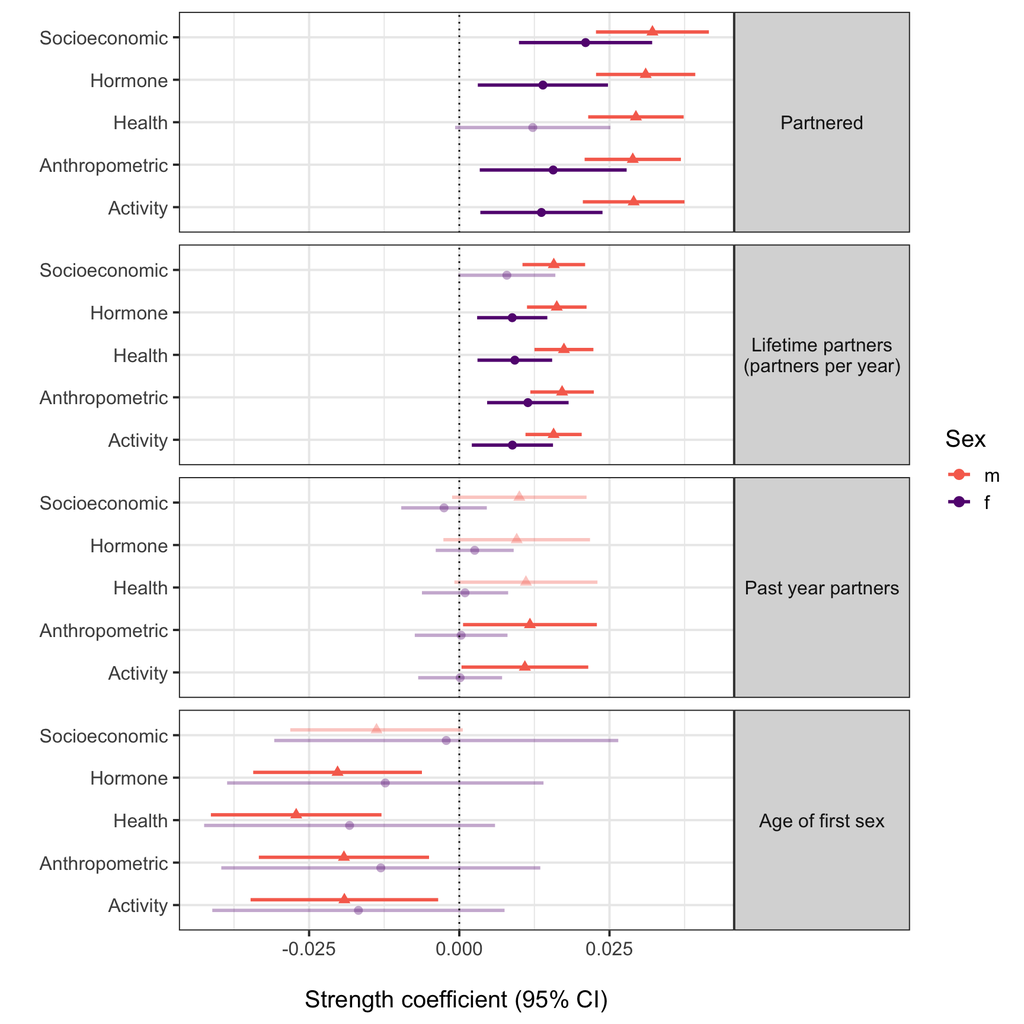

Figure S5: Grip strength coefficients in each regression model fit separately by sex. Control variables are the same as for models fit with a sex X grip strength interaction term. Note that these models test if each strength coefficient is significantly different from 0, not if the male and female coefficients are significantly different from each other.

#### Regression tables for sex-specific models of the effect of grip strength on mating success.

|  | Anthropometric | Socioeconomic | Health | Hormone | Activity |
| --- | --- | --- | --- | --- | --- |
| (Intercept) | 16.726 | 14.334 | 18.774 | 16.527 | 16.461 |
|  | (0.789) | (0.912) | (1.667) | (0.876) | (0.874) |
| Age | 0.041 | 0.051 | 0.046 | 0.040 | 0.039 |
|  | (0.007) | (0.008) | (0.008) | (0.008) | (0.008) |
| Grip Strength | -0.013 | -0.002 | -0.018 | -0.012 | -0.017 |
|  | (0.014) | (0.015) | (0.012) | (0.013) | (0.012) |
| Partnered | 0.193 | 0.059 | 0.080 | 0.248 | 0.158 |
|  | (0.312) | (0.294) | (0.275) | (0.321) | (0.296) |
| BMI | -0.007 |  |  |  |  |
|  | (0.015) |  |  |  |  |
| Other Hispanic |  | -0.490 |  |  |  |
|  |  | (0.579) |  |  |  |
| Non-Hispanic White |  | -1.909 |  |  |  |
|  |  | (0.456) |  |  |  |
| Non-Hispanic Black |  | -1.809 |  |  |  |
|  |  | (0.520) |  |  |  |
| Non-Hispanic Asian |  | 2.381 |  |  |  |
|  |  | (0.568) |  |  |  |
| Other Race |  | -0.986 |  |  |  |
|  |  | (0.487) |  |  |  |
| Education |  | 0.673 |  |  |  |
|  |  | (0.118) |  |  |  |
| Perceived Abnormal Weight |  |  | 0.085 |  |  |
|  |  |  | (0.211) |  |  |
| White Blood Cell Count |  |  | -0.079 |  |  |
|  |  |  | (0.064) |  |  |
| Hemoglobin |  |  | -0.078 |  |  |
|  |  |  | (0.145) |  |  |
| Need special equip to walk |  |  | 0.441 |  |  |
|  |  |  | (0.637) |  |  |
| Chronic Disease Score |  |  | -0.460 |  |  |
|  |  |  | (0.120) |  |  |
| Physical Disease Count |  |  | 0.261 |  |  |
|  |  |  | (0.299) |  |  |
| Depression Score |  |  | -0.105 |  |  |
|  |  |  | (0.036) |  |  |
| Testosterone |  |  |  | -0.002 |  |
|  |  |  |  | (0.002) |  |
| Vigorous Recreation |  |  |  |  | -0.014 |
|  |  |  |  |  | (0.226) |
| Moderate Recreation |  |  |  |  | 0.575 |
|  |  |  |  |  | (0.255) |
| Vigorous Work |  |  |  |  | -0.375 |
|  |  |  |  |  | (0.268) |
| Moderate Work |  |  |  |  | 0.339 |
|  |  |  |  |  | (0.264) |
| Num.Obs. | 1345 | 1354 | 1308 | 1265 | 1354 |

Table S11: Female Age of first sex ( GAUSSIAN ) regression model coefficients

|  | Anthropometric | Socioeconomic | Health | Hormone | Activity |
| --- | --- | --- | --- | --- | --- |
| (Intercept) | 18.699 | 15.395 | 18.946 | 18.721 | 17.937 |
|  | (0.953) | (0.861) | (1.999) | (0.948) | (0.823) |
| Age | 0.029 | 0.029 | 0.042 | 0.023 | 0.026 |
|  | (0.009) | (0.009) | (0.012) | (0.010) | (0.010) |
| Grip Strength | -0.019 | -0.014 | -0.027 | -0.020 | -0.019 |
|  | (0.007) | (0.007) | (0.007) | (0.007) | (0.008) |
| Partnered | 0.466 | 0.173 | 0.220 | 0.374 | 0.471 |
|  | (0.281) | (0.268) | (0.281) | (0.294) | (0.261) |
| BMI | -0.034 |  |  |  |  |
|  | (0.026) |  |  |  |  |
| Other Hispanic |  | -1.024 |  |  |  |
|  |  | (0.297) |  |  |  |
| Non-Hispanic White |  | -0.392 |  |  |  |
|  |  | (0.243) |  |  |  |
| Non-Hispanic Black |  | -1.481 |  |  |  |
|  |  | (0.285) |  |  |  |
| Non-Hispanic Asian |  | 3.461 |  |  |  |
|  |  | (0.361) |  |  |  |
| Other Race |  | -1.819 |  |  |  |
|  |  | (0.467) |  |  |  |
| Education |  | 0.627 |  |  |  |
|  |  | (0.108) |  |  |  |
| Perceived Abnormal Weight |  |  | -0.156 |  |  |
|  |  |  | (0.327) |  |  |
| White Blood Cell Count |  |  | -0.234 |  |  |
|  |  |  | (0.054) |  |  |
| Hemoglobin |  |  | 0.085 |  |  |
|  |  |  | (0.133) |  |  |
| Need special equip to walk |  |  | -0.474 |  |  |
|  |  |  | (0.996) |  |  |
| Chronic Disease Score |  |  | -0.433 |  |  |
|  |  |  | (0.212) |  |  |
| Physical Disease Count |  |  | -0.432 |  |  |
|  |  |  | (0.318) |  |  |
| Depression Score |  |  | -0.058 |  |  |
|  |  |  | (0.036) |  |  |
| Testosterone |  |  |  | -0.001 |  |
|  |  |  |  | (0.001) |  |
| Vigorous Recreation |  |  |  |  | 0.201 |
|  |  |  |  |  | (0.289) |
| Moderate Recreation |  |  |  |  | 0.180 |
|  |  |  |  |  | (0.315) |
| Vigorous Work |  |  |  |  | -0.665 |
|  |  |  |  |  | (0.311) |
| Moderate Work |  |  |  |  | -0.171 |
|  |  |  |  |  | (0.318) |
| Num.Obs. | 1387 | 1394 | 1336 | 1317 | 1394 |

Table S12: Male Age of first sex ( GAUSSIAN ) regression model coefficients

|  | Anthropometric | Socioeconomic | Health | Hormone | Activity |
| --- | --- | --- | --- | --- | --- |
| (Intercept) | -1.117 | -1.850 | -1.370 | -1.645 | -1.611 |
|  | (0.246) | (0.172) | (0.480) | (0.218) | (0.207) |
| Grip Strength | 0.011 | 0.008 | 0.009 | 0.009 | 0.009 |
|  | (0.003) | (0.004) | (0.003) | (0.003) | (0.003) |
| Partnered | -0.547 | -0.551 | -0.489 | -0.569 | -0.548 |
|  | (0.064) | (0.064) | (0.073) | (0.077) | (0.063) |
| BMI | -0.019 |  |  |  |  |
|  | (0.005) |  |  |  |  |
| Education |  | 0.013 |  |  |  |
|  |  | (0.059) |  |  |  |
| Other Hispanic |  | 0.047 |  |  |  |
|  |  | (0.142) |  |  |  |
| Non-Hispanic White |  | 0.409 |  |  |  |
|  |  | (0.140) |  |  |  |
| Non-Hispanic Black |  | 0.277 |  |  |  |
|  |  | (0.150) |  |  |  |
| Non-Hispanic Asian |  | -0.150 |  |  |  |
|  |  | (0.233) |  |  |  |
| Other Race |  | 0.563 |  |  |  |
|  |  | (0.196) |  |  |  |
| Perceived Abnormal Weight |  |  | -0.272 |  |  |
|  |  |  | (0.067) |  |  |
| White Blood Cell Count |  |  | 0.047 |  |  |
|  |  |  | (0.015) |  |  |
| Hemoglobin |  |  | -0.029 |  |  |
|  |  |  | (0.031) |  |  |
| Need special equip to walk |  |  | 0.135 |  |  |
|  |  |  | (0.188) |  |  |
| Chronic Disease Score |  |  | -0.086 |  |  |
|  |  |  | (0.051) |  |  |
| Physical Disease Count |  |  | -0.059 |  |  |
|  |  |  | (0.050) |  |  |
| Depression Score |  |  | 0.025 |  |  |
|  |  |  | (0.008) |  |  |
| Testosterone |  |  |  | 0.006 |  |
|  |  |  |  | (0.002) |  |
| Vigorous Recreation |  |  |  |  | 0.310 |
|  |  |  |  |  | (0.111) |
| Moderate Recreation |  |  |  |  | 0.046 |
|  |  |  |  |  | (0.068) |
| Vigorous Work |  |  |  |  | 0.085 |
|  |  |  |  |  | (0.113) |
| Moderate Work |  |  |  |  | -0.055 |
|  |  |  |  |  | (0.068) |
| Num.Obs. | 1388 | 1397 | 1352 | 1304 | 1397 |

Table S13: Female Lifetime partners (partners per year) ( QUASIPOISSON ) regression model coefficients

|  | Anthropometric | Socioeconomic | Health | Hormone | Activity |
| --- | --- | --- | --- | --- | --- |
| (Intercept) | -1.516 | -1.807 | -2.000 | -2.347 | -2.029 |
|  | (0.259) | (0.222) | (0.451) | (0.285) | (0.256) |
| Grip Strength | 0.017 | 0.016 | 0.017 | 0.016 | 0.016 |
|  | (0.003) | (0.003) | (0.003) | (0.003) | (0.002) |
| Partnered | -0.584 | -0.554 | -0.558 | -0.536 | -0.579 |
|  | (0.106) | (0.103) | (0.112) | (0.101) | (0.106) |
| BMI | -0.019 |  |  |  |  |
|  | (0.008) |  |  |  |  |
| Education |  | -0.034 |  |  |  |
|  |  | (0.021) |  |  |  |
| Other Hispanic |  | 0.352 |  |  |  |
|  |  | (0.120) |  |  |  |
| Non-Hispanic White |  | -0.104 |  |  |  |
|  |  | (0.092) |  |  |  |
| Non-Hispanic Black |  | 0.237 |  |  |  |
|  |  | (0.108) |  |  |  |
| Non-Hispanic Asian |  | -0.498 |  |  |  |
|  |  | (0.151) |  |  |  |
| Other Race |  | 0.255 |  |  |  |
|  |  | (0.217) |  |  |  |
| Perceived Abnormal Weight |  |  | -0.160 |  |  |
|  |  |  | (0.074) |  |  |
| White Blood Cell Count |  |  | 0.007 |  |  |
|  |  |  | (0.015) |  |  |
| Hemoglobin |  |  | -0.010 |  |  |
|  |  |  | (0.021) |  |  |
| Need special equip to walk |  |  | 0.196 |  |  |
|  |  |  | (0.156) |  |  |
| Chronic Disease Score |  |  | 0.056 |  |  |
|  |  |  | (0.051) |  |  |
| Physical Disease Count |  |  | 0.012 |  |  |
|  |  |  | (0.072) |  |  |
| Depression Score |  |  | 0.012 |  |  |
|  |  |  | (0.010) |  |  |
| Testosterone |  |  |  | 0.001 |  |
|  |  |  |  | (0.000) |  |
| Vigorous Recreation |  |  |  |  | 0.204 |
|  |  |  |  |  | (0.088) |
| Moderate Recreation |  |  |  |  | 0.059 |
|  |  |  |  |  | (0.078) |
| Vigorous Work |  |  |  |  | 0.025 |
|  |  |  |  |  | (0.068) |
| Moderate Work |  |  |  |  | -0.033 |
|  |  |  |  |  | (0.095) |
| Num.Obs. | 1449 | 1456 | 1390 | 1369 | 1456 |

Table S14: Male Lifetime partners (partners per year) ( QUASIPOISSON ) regression model coefficients

|  | Anthropometric | Socioeconomic | Health | Hormone | Activity |
| --- | --- | --- | --- | --- | --- |
| (Intercept) | -0.847 | -1.283 | -2.017 | -1.177 | -1.058 |
|  | (0.590) | (0.721) | (1.184) | (0.679) | (0.528) |
| Lifetime sex partners (S) | -0.436 | -0.446 | -0.384 | -0.453 | -0.440 |
|  | (0.070) | (0.082) | (0.071) | (0.078) | (0.071) |
| Age | 0.025 | 0.025 | 0.022 | 0.026 | 0.023 |
|  | (0.010) | (0.011) | (0.012) | (0.011) | (0.010) |
| Grip Strength | 0.016 | 0.021 | 0.012 | 0.014 | 0.014 |
|  | (0.006) | (0.006) | (0.007) | (0.006) | (0.005) |
| BMI | -0.011 |  |  |  |  |
|  | (0.014) |  |  |  |  |
| Education |  | 0.062 |  |  |  |
|  |  | (0.081) |  |  |  |
| Other Hispanic |  | -0.682 |  |  |  |
|  |  | (0.207) |  |  |  |
| Non-Hispanic White |  | -0.204 |  |  |  |
|  |  | (0.232) |  |  |  |
| Non-Hispanic Black |  | -1.583 |  |  |  |
|  |  | (0.221) |  |  |  |
| Non-Hispanic Asian |  | -0.335 |  |  |  |
|  |  | (0.250) |  |  |  |
| Other Race |  | -0.554 |  |  |  |
|  |  | (0.352) |  |  |  |
| Perceived Abnormal Weight |  |  | 0.250 |  |  |
|  |  |  | (0.201) |  |  |
| White Blood Cell Count |  |  | -0.025 |  |  |
|  |  |  | (0.040) |  |  |
| Hemoglobin |  |  | 0.103 |  |  |
|  |  |  | (0.074) |  |  |
| Need special equip to walk |  |  | -0.049 |  |  |
|  |  |  | (0.338) |  |  |
| Chronic Disease Score |  |  | 0.063 |  |  |
|  |  |  | (0.172) |  |  |
| Physical Disease Count |  |  | -0.203 |  |  |
|  |  |  | (0.110) |  |  |
| Depression Score |  |  | -0.052 |  |  |
|  |  |  | (0.016) |  |  |
| Testosterone |  |  |  | 0.005 |  |
|  |  |  |  | (0.003) |  |
| Vigorous Recreation |  |  |  |  | -0.147 |
|  |  |  |  |  | (0.149) |
| Moderate Recreation |  |  |  |  | 0.350 |
|  |  |  |  |  | (0.162) |
| Vigorous Work |  |  |  |  | 0.071 |
|  |  |  |  |  | (0.131) |
| Moderate Work |  |  |  |  | -0.134 |
|  |  |  |  |  | (0.168) |
| Num.Obs. | 1388 | 1397 | 1352 | 1304 | 1397 |

Table S15: Female Partnered ( QUASIBINOMIAL ) regression model coefficients

|  | Anthropometric | Socioeconomic | Health | Hormone | Activity |
| --- | --- | --- | --- | --- | --- |
| (Intercept) | -4.564 | -4.266 | -2.619 | -3.778 | -4.274 |
|  | (0.779) | (0.849) | (1.197) | (0.666) | (0.709) |
| Lifetime sex partners (S) | -0.279 | -0.261 | -0.261 | -0.264 | -0.276 |
|  | (0.067) | (0.067) | (0.069) | (0.068) | (0.066) |
| Age | 0.059 | 0.064 | 0.062 | 0.056 | 0.058 |
|  | (0.012) | (0.013) | (0.014) | (0.012) | (0.011) |
| Grip Strength | 0.029 | 0.032 | 0.029 | 0.031 | 0.029 |
|  | (0.004) | (0.005) | (0.004) | (0.004) | (0.004) |
| BMI | 0.010 |  |  |  |  |
|  | (0.010) |  |  |  |  |
| Education |  | 0.099 |  |  |  |
|  |  | (0.089) |  |  |  |
| Other Hispanic |  | -0.643 |  |  |  |
|  |  | (0.260) |  |  |  |
| Non-Hispanic White |  | -1.000 |  |  |  |
|  |  | (0.209) |  |  |  |
| Non-Hispanic Black |  | -1.453 |  |  |  |
|  |  | (0.277) |  |  |  |
| Non-Hispanic Asian |  | -0.554 |  |  |  |
|  |  | (0.263) |  |  |  |
| Other Race |  | -1.303 |  |  |  |
|  |  | (0.491) |  |  |  |
| Perceived Abnormal Weight |  |  | 0.333 |  |  |
|  |  |  | (0.136) |  |  |
| White Blood Cell Count |  |  | -0.026 |  |  |
|  |  |  | (0.037) |  |  |
| Hemoglobin |  |  | -0.113 |  |  |
|  |  |  | (0.075) |  |  |
| Need special equip to walk |  |  | 0.385 |  |  |
|  |  |  | (0.486) |  |  |
| Chronic Disease Score |  |  | 0.019 |  |  |
|  |  |  | (0.121) |  |  |
| Physical Disease Count |  |  | -0.321 |  |  |
|  |  |  | (0.131) |  |  |
| Depression Score |  |  | -0.020 |  |  |
|  |  |  | (0.018) |  |  |
| Testosterone |  |  |  | -0.001 |  |
|  |  |  |  | (0.000) |  |
| Vigorous Recreation |  |  |  |  | -0.236 |
|  |  |  |  |  | (0.158) |
| Moderate Recreation |  |  |  |  | 0.126 |
|  |  |  |  |  | (0.201) |
| Vigorous Work |  |  |  |  | -0.109 |
|  |  |  |  |  | (0.094) |
| Moderate Work |  |  |  |  | 0.200 |
|  |  |  |  |  | (0.140) |
| Num.Obs. | 1449 | 1456 | 1390 | 1369 | 1456 |

Table S16: Male Partnered ( QUASIBINOMIAL ) regression model coefficients

|  | Anthropometric | Socioeconomic | Health | Hormone | Activity |
| --- | --- | --- | --- | --- | --- |
| (Intercept) | 0.044 | -0.076 | 0.224 | -0.197 | 0.052 |
|  | (0.221) | (0.237) | (0.270) | (0.187) | (0.188) |
| Age (S) | -0.393 | -0.409 | -0.405 | -0.440 | -0.396 |
|  | (0.066) | (0.062) | (0.055) | (0.057) | (0.061) |
| Grip Strength | 0.000 | -0.003 | 0.001 | 0.003 | 0.000 |
|  | (0.004) | (0.004) | (0.004) | (0.003) | (0.004) |
| Partnered | -0.202 | -0.209 | -0.139 | 0.037 | -0.211 |
|  | (0.251) | (0.248) | (0.249) | (0.207) | (0.225) |
| BMI | -0.002 |  |  |  |  |
|  | (0.003) |  |  |  |  |
| strength:partneredTRUE | 0.003 | 0.004 | 0.003 | 0.000 | 0.003 |
|  | (0.004) | (0.004) | (0.004) | (0.003) | (0.004) |
| Education |  | 0.034 |  |  |  |
|  |  | (0.027) |  |  |  |
| Other Hispanic |  | 0.039 |  |  |  |
|  |  | (0.096) |  |  |  |
| Non-Hispanic White |  | 0.040 |  |  |  |
|  |  | (0.064) |  |  |  |
| Non-Hispanic Black |  | 0.248 |  |  |  |
|  |  | (0.094) |  |  |  |
| Non-Hispanic Asian |  | -0.109 |  |  |  |
|  |  | (0.112) |  |  |  |
| Other Race |  | 0.174 |  |  |  |
|  |  | (0.152) |  |  |  |
| Perceived Abnormal Weight |  |  | -0.082 |  |  |
|  |  |  | (0.049) |  |  |
| White Blood Cell Count |  |  | 0.003 |  |  |
|  |  |  | (0.012) |  |  |
| Hemoglobin |  |  | -0.023 |  |  |
|  |  |  | (0.018) |  |  |
| Need special equip to walk |  |  | 0.003 |  |  |
|  |  |  | (0.142) |  |  |
| Chronic Disease Score |  |  | 0.021 |  |  |
|  |  |  | (0.033) |  |  |
| Physical Disease Count |  |  | -0.001 |  |  |
|  |  |  | (0.029) |  |  |
| Depression Score |  |  | 0.004 |  |  |
|  |  |  | (0.006) |  |  |
| Testosterone |  |  |  | 0.000 |  |
|  |  |  |  | (0.001) |  |
| Vigorous Recreation |  |  |  |  | 0.032 |
|  |  |  |  |  | (0.047) |
| Moderate Recreation |  |  |  |  | -0.021 |
|  |  |  |  |  | (0.067) |
| Vigorous Work |  |  |  |  | 0.096 |
|  |  |  |  |  | (0.072) |
| Moderate Work |  |  |  |  | -0.229 |
|  |  |  |  |  | (0.105) |
| Num.Obs. | 1351 | 1360 | 1315 | 1270 | 1360 |

Table S17: Female Past year partners ( QUASIPOISSON ) regression model coefficients

|  | Anthropometric | Socioeconomic | Health | Hormone | Activity |
| --- | --- | --- | --- | --- | --- |
| (Intercept) | 0.098 | -0.153 | -0.736 | -0.508 | -0.571 |
|  | (0.507) | (0.607) | (0.817) | (0.683) | (0.552) |
| Age (S) | -0.348 | -0.413 | -0.452 | -0.420 | -0.423 |
|  | (0.160) | (0.176) | (0.212) | (0.198) | (0.178) |
| Grip Strength | 0.012 | 0.010 | 0.011 | 0.010 | 0.011 |
|  | (0.006) | (0.006) | (0.006) | (0.006) | (0.005) |
| Partnered | 0.755 | 0.800 | 0.889 | 0.805 | 0.892 |
|  | (0.511) | (0.563) | (0.608) | (0.580) | (0.521) |
| BMI | -0.025 |  |  |  |  |
|  | (0.009) |  |  |  |  |
| strength:partneredTRUE | -0.012 | -0.012 | -0.013 | -0.012 | -0.014 |
|  | (0.005) | (0.006) | (0.006) | (0.006) | (0.006) |
| Education |  | -0.123 |  |  |  |
|  |  | (0.060) |  |  |  |
| Other Hispanic |  | 0.360 |  |  |  |
|  |  | (0.203) |  |  |  |
| Non-Hispanic White |  | 0.086 |  |  |  |
|  |  | (0.201) |  |  |  |
| Non-Hispanic Black |  | 0.449 |  |  |  |
|  |  | (0.203) |  |  |  |
| Non-Hispanic Asian |  | -0.016 |  |  |  |
|  |  | (0.205) |  |  |  |
| Other Race |  | 0.400 |  |  |  |
|  |  | (0.244) |  |  |  |
| Perceived Abnormal Weight |  |  | -0.233 |  |  |
|  |  |  | (0.099) |  |  |
| White Blood Cell Count |  |  | 0.042 |  |  |
|  |  |  | (0.024) |  |  |
| Hemoglobin |  |  | -0.006 |  |  |
|  |  |  | (0.029) |  |  |
| Need special equip to walk |  |  | -0.058 |  |  |
|  |  |  | (0.290) |  |  |
| Chronic Disease Score |  |  | 0.164 |  |  |
|  |  |  | (0.168) |  |  |
| Physical Disease Count |  |  | -0.017 |  |  |
|  |  |  | (0.076) |  |  |
| Depression Score |  |  | 0.006 |  |  |
|  |  |  | (0.014) |  |  |
| Testosterone |  |  |  | 0.000 |  |
|  |  |  |  | (0.001) |  |
| Vigorous Recreation |  |  |  |  | -0.048 |
|  |  |  |  |  | (0.136) |
| Moderate Recreation |  |  |  |  | 0.130 |
|  |  |  |  |  | (0.134) |
| Vigorous Work |  |  |  |  | 0.179 |
|  |  |  |  |  | (0.104) |
| Moderate Work |  |  |  |  | -0.110 |
|  |  |  |  |  | (0.094) |
| Num.Obs. | 1412 | 1418 | 1352 | 1332 | 1418 |

Table S18: Male Past year partners ( QUASIPOISSON ) regression model coefficients

## Stage 2: Confirmatory study

### Descriptive statistics

| **Variable** | **Male** **N** | **Male** **Mean (SD)**<sup>1</sup> | **Female** **N** | **Female** **Mean (SD)**<sup>1</sup> | **Sexual Dimorphism** **Ratio** | **Sexual Dimorphism** **SMD**<sup>2</sup> |
| --- | --- | --- | --- | --- | --- | --- |
| Age (Years) | 2,035 | 38.69 (12.62) | 2,281 | 38.89 (12.38) | 0.99 | -0.02 |
| Age at first sex (years) | 1,663 | 17.05 (3.61) | 1,840 | 17.52 (3.45) | 0.97 | -0.13 |
| Lifetime number of sexual partners | 1,765 | 11.38 (14.16) | 1,937 | 7.18 (8.71) | 1.58 | 0.36 |
| Past year number of sexual partners | 1,729 | 1.41 (1.97) | 1,890 | 1.08 (1.34) | 1.31 | 0.20 |
| Combined Grip Strength (kg) | 1,854 | 93.98 (16.69) | 2,036 | 59.53 (10.41) | 1.58 | 2.48 |
| Arm lean mass (g) | 1,716 | 7,935.69 (1,531.03) | 1,800 | 4,563.79 (992.42) | 1.74 | 2.61 |
| Leg lean mass (g) | 1,678 | 19,330.75 (3,709.97) | 1,784 | 13,879.44 (3,355.89) | 1.39 | 1.54 |
| Trunk lean mass (g) | 1,748 | 30,351.69 (5,938.49) | 1,773 | 22,725.70 (4,842.25) | 1.34 | 1.41 |
| Total lean mass (g) | 1,637 | 60,803.54 (10,671.50) | 1,739 | 43,891.24 (8,997.17) | 1.39 | 1.71 |
| Body mass index (kg/m^2) | 1,951 | 28.65 (6.35) | 2,189 | 29.42 (8.20) | 0.97 | -0.11 |
| Height (cm) | 1,951 | 176.20 (7.60) | 2,193 | 162.56 (6.77) | 1.08 | 1.90 |
| Weight (kg) | 1,953 | 89.17 (21.47) | 2,190 | 77.82 (22.56) | 1.15 | 0.52 |
| White blood cell count (1000 cells/µL) | 1,884 | 7.31 (2.25) | 2,131 | 7.65 (2.38) | 0.96 | -0.15 |
| Hemoglobin (g/dL) | 1,884 | 15.19 (1.11) | 2,131 | 13.32 (1.20) | 1.14 | 1.62 |
| Testosterone (ng/dL) | 1,858 | 412.87 (165.20) | 2,097 | 25.65 (24.88) | 16.10 | 3.28 |
| Chronic Disease Score (0-6) | 1,865 | 0.43 (0.68) | 2,087 | 0.60 (0.84) | 0.72 | -0.22 |
| Disease Impairment Score (0-5) | 2,035 | 0.22 (0.77) | 2,281 | 0.36 (0.97) | 0.61 | -0.17 |
| Depression Score (0-27) | 1,792 | 2.34 (3.51) | 1,974 | 3.79 (4.68) | 0.62 | -0.35 |
| Dietary energy intake (kcals) | 1,518 | 2,483.91 (937.47) | 1,829 | 1,843.39 (632.98) | 1.35 | 0.80 |
| Dietary protein intake (grams) | 1,518 | 99.69 (42.33) | 1,829 | 72.49 (28.21) | 1.38 | 0.76 |
| Food Insecurity Rating (1-4) | 2,004 | 1.49 (0.92) | 2,248 | 1.54 (0.95) | 0.97 | -0.05 |
| Total MET | 2,028 | 83.84 (118.92) | 2,275 | 43.43 (76.35) | 1.93 | 0.40 |
| Partnered | 1,876 | 1,167 (64%) | 2,095 | 1,211 (61%) |  |  |
| Education |  |  |  |  |  |  |
| 1 | 2,035 | 126 (4.5%) | 2,279 | 116 (3.2%) |  |  |
| 2 | 2,035 | 335 (13%) | 2,279 | 328 (12%) |  |  |
| 3 | 2,035 | 503 (24%) | 2,279 | 496 (20%) |  |  |
| 4 | 2,035 | 575 (29%) | 2,279 | 789 (36%) |  |  |
| 5 | 2,035 | 496 (30%) | 2,279 | 550 (29%) |  |  |
| Race and Ethnicity |  |  |  |  |  |  |
| MexicanAmerican | 2,035 | 310 (12%) | 2,281 | 339 (10%) |  |  |
| OtherHispanic | 2,035 | 169 (6.0%) | 2,281 | 224 (6.6%) |  |  |
| NonHispanicWhite | 2,035 | 818 (62%) | 2,281 | 862 (61%) |  |  |
| NonHispanicBlack | 2,035 | 395 (11%) | 2,281 | 481 (13%) |  |  |
| NonHispanicAsian | 2,035 | 263 (5.5%) | 2,281 | 287 (6.0%) |  |  |
| OtherRace | 2,035 | 80 (3.6%) | 2,281 | 88 (2.8%) |  |  |
| Perceived abnormal weight | 2,030 | 1,003 (53%) | 2,278 | 1,454 (64%) |  |  |
| Special equipment needed to walk | 1,877 | 79 (3.1%) | 2,095 | 115 (4.8%) |  |  |
| Work involves vigorous activity | 2,034 | 622 (31%) | 2,281 | 284 (12%) |  |  |
| Work involves moderate activity | 2,034 | 820 (43%) | 2,281 | 744 (33%) |  |  |
| Recreation involves vigorous activity | 2,035 | 728 (35%) | 2,281 | 519 (25%) |  |  |
| Recreation involves moderate activity | 2,035 | 850 (45%) | 2,281 | 976 (46%) |  |  |

<sup>1</sup> Weighted means and standard deviations shown for continuous variables, unweighted n (%) for categorical variables  
<sup>2</sup> Standardized Mean Difference

Table S19: Confirmatory: Descriptive statistics and sex differences for participants ages 18-60 using population weights

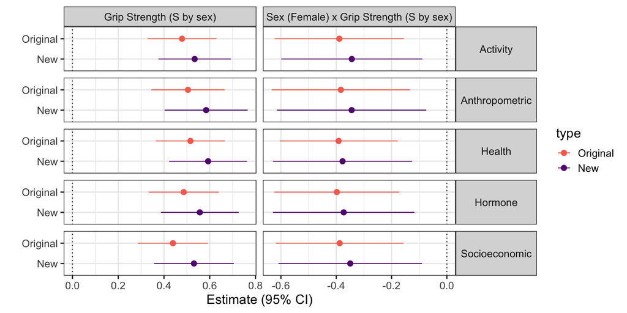

Figure S6: Pilot: A comparison of grip strength and $grip\ strength\times sex$ coefficients with the original model specification for lifetime sexual partners (anthropometric controls) that included age as a control variable (original), and the specification that now instead includes years since sexual maturity (age-12) as an exposure variable (offset) (new). Both models are quasi-Poisson models.

### Marginal effects

| sex | partnered | estimate |
| --- | --- | --- |
| male |  | 0.12 |
| female |  | 0.024 |
| male | FALSE | 0.27 |
| male | TRUE | 0.16 |
| female | FALSE | 0.14 |
| female | TRUE | 0.084 |
| male | FALSE | 0.29 |
| male | TRUE | 0.12 |
| female | FALSE | 0.16 |
| female | TRUE | 0.049 |
| male |  | -0.38 |
| female |  | -0.50 |

Table S20: Confirmatory: The average marginal effect of a 2 standard deviation increase in grip strength on each mating outcome, by sex and partnered status, for the models with anthropometric controls.

### Correlation matrices of study variables

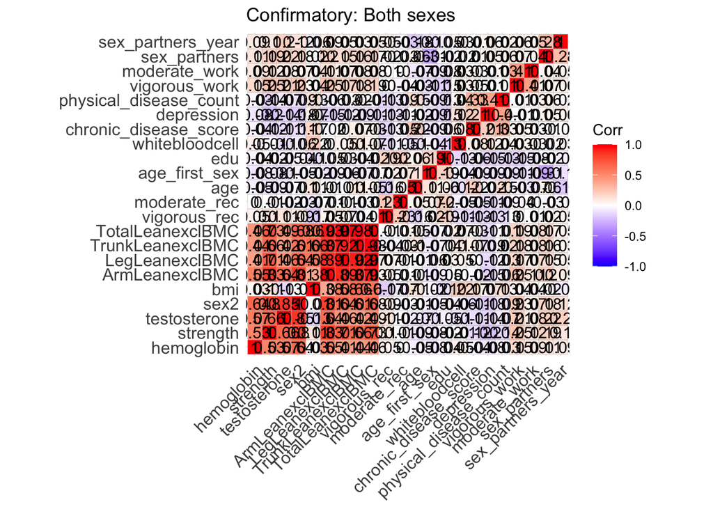

Figure S7: Confirmatory: Correlation matrix of study variables (both sexes). Rows and columns ordered by hierarchical clustering.

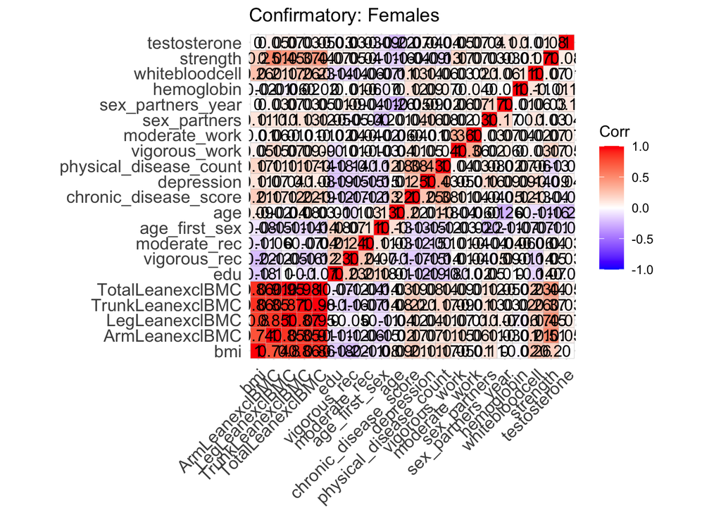

Figure S8: Confirmatory: Correlation matrix of study variables for females only. Rows and columns ordered by hierarchical clustering.

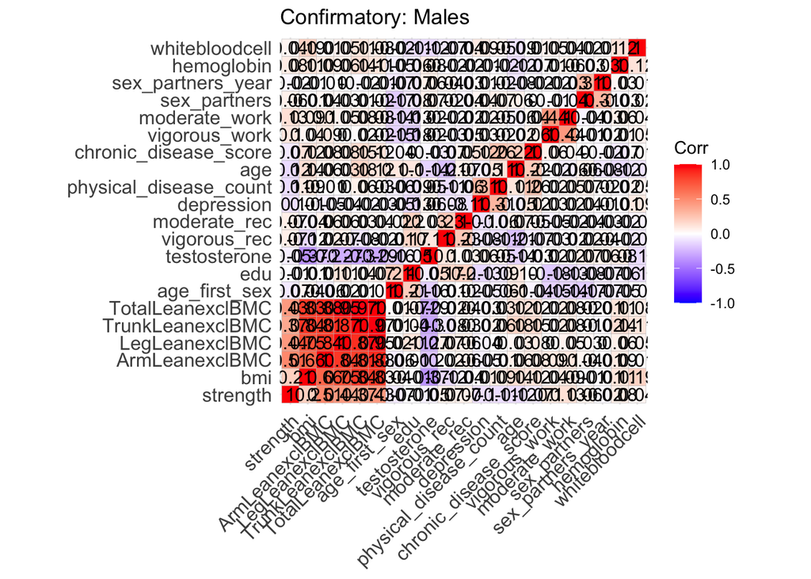

Figure S9: Confirmatory: Correlation matrix of study variables for males only. Rows and columns ordered by hierarchical clustering.

### Regression tables (confirmatory study)

|  | Anthropometric | Socioeconomic | Health | Hormone | Activity |
| --- | --- | --- | --- | --- | --- |
| (Intercept) | 16.688 | 15.331 | 16.688 | 16.814 | 16.745 |
|  | (0.132) | (0.353) | (0.132) | (0.151) | (0.161) |
| Age (S) | 0.214 | 0.376 | 0.214 | 0.154 | 0.218 |
|  | (0.264) | (0.252) | (0.264) | (0.281) | (0.253) |
| Sex (Female) | 0.473 | 0.423 | 0.473 | 0.399 | 0.362 |
|  | (0.082) | (0.065) | (0.082) | (0.075) | (0.091) |
| Grip Strength (S by sex) | -0.381 | -0.029 | -0.381 | -0.454 | -0.336 |
|  | (0.199) | (0.214) | (0.199) | (0.190) | (0.210) |
| Partnered | 0.672 | 0.375 | 0.672 | 0.539 | 0.634 |
|  | (0.152) | (0.161) | (0.152) | (0.180) | (0.157) |
| BMI (S) | 0.072 |  | 0.072 |  |  |
|  | (0.191) |  | (0.191) |  |  |
| Age (S) x Sex (Female) | 0.660 | 0.547 | 0.660 | 0.495 | 0.532 |
|  | (0.222) | (0.217) | (0.222) | (0.206) | (0.222) |
| Sex (Female) x Grip Strength (S by sex) | -0.117 | -0.296 | -0.117 | -0.099 | -0.239 |
|  | (0.185) | (0.174) | (0.185) | (0.187) | (0.198) |
| Sex (Female) x BMI (S) | -0.524 |  | -0.524 |  |  |
|  | (0.216) |  | (0.216) |  |  |
| Other Hispanic |  | 0.226 |  |  |  |
|  |  | (0.385) |  |  |  |
| Non-Hispanic White |  | -0.810 |  |  |  |
|  |  | (0.187) |  |  |  |
| Non-Hispanic Black |  | -1.463 |  |  |  |
|  |  | (0.167) |  |  |  |
| Non-Hispanic Asian |  | 3.202 |  |  |  |
|  |  | (0.392) |  |  |  |
| Other Race |  | -0.526 |  |  |  |
|  |  | (0.347) |  |  |  |
| Education |  | 0.551 |  |  |  |
|  |  | (0.097) |  |  |  |
| Testosterone (S by Sex) |  |  |  | -0.801 |  |
|  |  |  |  | (0.241) |  |
| Sex (Female) x Testosterone (S by Sex) |  |  |  | 0.488 |  |
|  |  |  |  | (0.299) |  |
| Vigorous Recreation |  |  |  |  | 0.192 |
|  |  |  |  |  | (0.156) |
| Moderate Recreation |  |  |  |  | 0.413 |
|  |  |  |  |  | (0.153) |
| Vigorous Work |  |  |  |  | -0.444 |
|  |  |  |  |  | (0.173) |
| Moderate Work |  |  |  |  | -0.342 |
|  |  |  |  |  | (0.167) |
| Num.Obs. | 3127 | 3140 | 3127 | 3019 | 3140 |

Table S21: Age of first sex ( GAUSSIAN ) regression model coefficients

|  | Lassek and Gaulin | Expanded controls |
| --- | --- | --- |
| (Intercept) | 2335.911 | 2311.752 |
|  | (27.839) | (51.744) |
| Age (S) | -99.686 | -104.788 |
|  | (49.086) | (49.561) |
| Total MET (S) | 137.194 | 151.992 |
|  | (58.666) | (64.429) |
| Grip Strength (S) | 274.515 | 185.121 |
|  | (61.843) | (67.021) |
| BMI (S) | -25.196 |  |
|  | (39.065) |  |
| Sex (Female) | -378.090 | -334.365 |
|  | (47.950) | (59.512) |
| Weight (S) |  | -8.634 |
|  |  | (46.237) |
| Height (S) |  | 155.289 |
|  |  | (62.748) |
| White Blood Cell Count (S) |  | 11.933 |
|  |  | (47.455) |
| Food Insecurity |  | -0.336 |
|  |  | (19.626) |
| Num.Obs. | 3224 | 3112 |

Table S22: Energy (kcal) ( GAUSSIAN ) regression model coefficients

|  | Lassek and Gaulin | Expanded controls |
| --- | --- | --- |
| (Intercept) | 1.997 | 1.988 |
|  | (0.009) | (0.018) |
| Age (S) | -0.056 | -0.056 |
|  | (0.016) | (0.018) |
| Sex (Female) | 0.023 | 0.005 |
|  | (0.014) | (0.028) |
| Grip Strength (S) | -0.027 | 0.023 |
|  | (0.019) | (0.035) |
| BMI (S) | 0.144 |  |
|  | (0.012) |  |
| Age (S) x Sex (Female) | -0.058 | -0.029 |
|  | (0.026) | (0.030) |
| Sex (Female) x Strength (S) | 0.000 | -0.011 |
|  | (0.042) | (0.065) |
| Weight (S) |  | 0.138 |
|  |  | (0.018) |
| Height (S) |  | -0.135 |
|  |  | (0.021) |
| Testosterone (S by Sex) |  | -0.040 |
|  |  | (0.022) |
| Food Insecurity |  | 0.007 |
|  |  | (0.009) |
| Average calories per day (S) |  | 0.001 |
|  |  | (0.019) |
| Total MET (S) |  | 0.025 |
|  |  | (0.015) |
| Depression Score |  | 0.005 |
|  |  | (0.002) |
| Sex (Female) x Testosterone (S by Sex) |  | 0.079 |
|  |  | (0.035) |
| Num.Obs. | 3790 | 2956 |

Table S23: Immunity ( QUASIPOISSON ) regression model coefficients

|  | Anthropometric | Socioeconomic | Health | Hormone | Activity |
| --- | --- | --- | --- | --- | --- |
| (Intercept) | -0.517 | -0.608 | -0.478 | -0.553 | -0.578 |
|  | (0.055) | (0.115) | (0.058) | (0.055) | (0.066) |
| Grip Strength (S by sex) | 0.368 | 0.310 | 0.342 | 0.358 | 0.318 |
|  | (0.061) | (0.057) | (0.060) | (0.052) | (0.056) |
| Sex (Female) | -0.527 | -0.536 | -0.547 | -0.516 | -0.499 |
|  | (0.054) | (0.052) | (0.064) | (0.050) | (0.058) |
| Partnered | -0.515 | -0.469 | -0.491 | -0.469 | -0.499 |
|  | (0.049) | (0.049) | (0.042) | (0.046) | (0.048) |
| BMI (S) | -0.128 |  |  |  |  |
|  | (0.091) |  |  |  |  |
| Sex (Female) x Grip Strength (S by sex) | -0.036 | -0.037 | 0.003 | -0.060 | -0.008 |
|  | (0.079) | (0.070) | (0.074) | (0.065) | (0.072) |
| Sex (Female) x BMI (S) | 0.085 |  |  |  |  |
|  | (0.114) |  |  |  |  |
| Education |  | -0.021 |  |  |  |
|  |  | (0.027) |  |  |  |
| Other Hispanic |  | 0.188 |  |  |  |
|  |  | (0.130) |  |  |  |
| Non-Hispanic White |  | 0.135 |  |  |  |
|  |  | (0.092) |  |  |  |
| Non-Hispanic Black |  | 0.360 |  |  |  |
|  |  | (0.085) |  |  |  |
| Non-Hispanic Asian |  | -0.401 |  |  |  |
|  |  | (0.157) |  |  |  |
| Other Race |  | 0.334 |  |  |  |
|  |  | (0.137) |  |  |  |
| Perceived Abnormal Weight |  |  | -0.116 |  |  |
|  |  |  | (0.065) |  |  |
| White Blood Cell Count (S) |  |  | 0.082 |  |  |
|  |  |  | (0.048) |  |  |
| Hemoglobin (S) |  |  | -0.003 |  |  |
|  |  |  | (0.067) |  |  |
| Need special equip to walk |  |  | -0.045 |  |  |
|  |  |  | (0.180) |  |  |
| Chronic Disease Score |  |  | -0.087 |  |  |
|  |  |  | (0.044) |  |  |
| Physical Disease Count |  |  | -0.012 |  |  |
|  |  |  | (0.037) |  |  |
| Depression Score |  |  | 0.026 |  |  |
|  |  |  | (0.007) |  |  |
| Testosterone (S by Sex) |  |  |  | 0.258 |  |
|  |  |  |  | (0.083) |  |
| Sex (Female) x Testosterone (S by Sex) |  |  |  | -0.100 |  |
|  |  |  |  | (0.078) |  |
| Vigorous Recreation |  |  |  |  | 0.217 |
|  |  |  |  |  | (0.091) |
| Moderate Recreation |  |  |  |  | -0.173 |
|  |  |  |  |  | (0.054) |
| Vigorous Work |  |  |  |  | 0.045 |
|  |  |  |  |  | (0.075) |
| Moderate Work |  |  |  |  | 0.103 |
|  |  |  |  |  | (0.073) |
| Num.Obs. | 3231 | 3244 | 3137 | 3120 | 3244 |

Table S24: Lifetime partners (partners per year) ( QUASIPOISSON ) regression model coefficients

|  | Anthropometric | Socioeconomic | Health | Hormone | Activity |
| --- | --- | --- | --- | --- | --- |
| (Intercept) | 0.970 | 0.979 | 1.201 | 0.970 | 1.017 |
|  | (0.070) | (0.219) | (0.109) | (0.068) | (0.110) |
| Lifetime sex partners (S) | -0.267 | -0.235 | -0.251 | -0.247 | -0.266 |
|  | (0.034) | (0.034) | (0.033) | (0.032) | (0.035) |
| Age (S) | 1.766 | 1.816 | 1.919 | 1.757 | 1.785 |
|  | (0.167) | (0.175) | (0.169) | (0.166) | (0.162) |
| Sex (Female) | -0.329 | -0.298 | -0.372 | -0.344 | -0.337 |
|  | (0.070) | (0.067) | (0.104) | (0.064) | (0.083) |
| Grip Strength (S by sex) | 0.685 | 0.830 | 0.687 | 0.698 | 0.766 |
|  | (0.139) | (0.136) | (0.142) | (0.143) | (0.141) |
| BMI (S) | 0.203 |  |  |  |  |
|  | (0.156) |  |  |  |  |
| Age (S) x Sex (Female) | -1.227 | -1.262 | -1.216 | -1.283 | -1.281 |
|  | (0.229) | (0.226) | (0.230) | (0.229) | (0.229) |
| Sex (Female) x Grip Strength (S by sex) | -0.578 | -0.588 | -0.691 | -0.625 | -0.661 |
|  | (0.166) | (0.160) | (0.185) | (0.190) | (0.157) |
| Sex (Female) x BMI (S) | -0.304 |  |  |  |  |
|  | (0.174) |  |  |  |  |
| Education |  | 0.066 |  |  |  |
|  |  | (0.053) |  |  |  |
| Other Hispanic |  | -0.072 |  |  |  |
|  |  | (0.231) |  |  |  |
| Non-Hispanic White |  | -0.228 |  |  |  |
|  |  | (0.207) |  |  |  |
| Non-Hispanic Black |  | -1.276 |  |  |  |
|  |  | (0.188) |  |  |  |
| Non-Hispanic Asian |  | 0.122 |  |  |  |
|  |  | (0.179) |  |  |  |
| Other Race |  | -0.578 |  |  |  |
|  |  | (0.180) |  |  |  |
| Perceived Abnormal Weight |  |  | 0.020 |  |  |
|  |  |  | (0.085) |  |  |
| White Blood Cell Count (S) |  |  | 0.064 |  |  |
|  |  |  | (0.083) |  |  |
| Hemoglobin (S) |  |  | -0.179 |  |  |
|  |  |  | (0.134) |  |  |
| Need special equip to walk |  |  | -0.556 |  |  |
|  |  |  | (0.217) |  |  |
| Chronic Disease Score |  |  | -0.154 |  |  |
|  |  |  | (0.071) |  |  |
| Physical Disease Count |  |  | -0.062 |  |  |
|  |  |  | (0.055) |  |  |
| Depression Score |  |  | -0.034 |  |  |
|  |  |  | (0.014) |  |  |
| Testosterone (S by Sex) |  |  |  | -0.887 |  |
|  |  |  |  | (0.124) |  |
| Sex (Female) x Testosterone (S by Sex) |  |  |  | 0.830 |  |
|  |  |  |  | (0.142) |  |
| Vigorous Recreation |  |  |  |  | 0.036 |
|  |  |  |  |  | (0.088) |
| Moderate Recreation |  |  |  |  | 0.019 |
|  |  |  |  |  | (0.086) |
| Vigorous Work |  |  |  |  | 0.020 |
|  |  |  |  |  | (0.108) |
| Moderate Work |  |  |  |  | -0.196 |
|  |  |  |  |  | (0.117) |
| Num.Obs. | 3231 | 3244 | 3137 | 3120 | 3244 |

Table S25: Partnered ( QUASIBINOMIAL ) regression model coefficients

|  | Anthropometric | Socioeconomic | Health | Hormone | Activity |
| --- | --- | --- | --- | --- | --- |
| (Intercept) | 0.481 | 0.519 | 0.480 | 0.461 | 0.430 |
|  | (0.097) | (0.153) | (0.081) | (0.091) | (0.112) |
| Age (S) | -0.268 | -0.291 | -0.270 | -0.231 | -0.262 |
|  | (0.048) | (0.060) | (0.070) | (0.058) | (0.065) |
| Sex (Female) | -0.283 | -0.298 | -0.344 | -0.288 | -0.265 |
|  | (0.075) | (0.075) | (0.083) | (0.067) | (0.086) |
| Grip Strength (S by sex) | 0.155 | 0.046 | 0.086 | 0.055 | 0.049 |
|  | (0.115) | (0.130) | (0.124) | (0.127) | (0.129) |
| Partnered | -0.268 | -0.249 | -0.255 | -0.235 | -0.278 |
|  | (0.086) | (0.088) | (0.080) | (0.085) | (0.087) |
| BMI (S) | -0.169 |  |  |  |  |
|  | (0.087) |  |  |  |  |
| Age (S) x Sex (Female) | -0.150 | -0.147 | -0.170 | -0.193 | -0.153 |
|  | (0.079) | (0.089) | (0.093) | (0.102) | (0.093) |
| Sex (Female) x Grip Strength (S by sex) | -0.040 | 0.011 | 0.034 | 0.014 | 0.017 |
|  | (0.067) | (0.094) | (0.075) | (0.090) | (0.092) |
| Partnered x Grip Strength (S by sex) | -0.063 | -0.027 | -0.035 | 0.010 | -0.022 |
|  | (0.097) | (0.106) | (0.116) | (0.107) | (0.105) |
| Sex (Female) x BMI (S) | 0.123 |  |  |  |  |
|  | (0.105) |  |  |  |  |
| Education |  | -0.050 |  |  |  |
|  |  | (0.028) |  |  |  |
| Other Hispanic |  | 0.048 |  |  |  |
|  |  | (0.079) |  |  |  |
| Non-Hispanic White |  | 0.161 |  |  |  |
|  |  | (0.075) |  |  |  |
| Non-Hispanic Black |  | 0.298 |  |  |  |
|  |  | (0.045) |  |  |  |
| Non-Hispanic Asian |  | 0.004 |  |  |  |
|  |  | (0.065) |  |  |  |
| Other Race |  | 0.232 |  |  |  |
|  |  | (0.107) |  |  |  |
| Perceived Abnormal Weight |  |  | -0.084 |  |  |
|  |  |  | (0.049) |  |  |
| White Blood Cell Count (S) |  |  | 0.030 |  |  |
|  |  |  | (0.038) |  |  |
| Hemoglobin (S) |  |  | -0.010 |  |  |
|  |  |  | (0.066) |  |  |
| Need special equip to walk |  |  | 0.004 |  |  |
|  |  |  | (0.178) |  |  |
| Chronic Disease Score |  |  | 0.048 |  |  |
|  |  |  | (0.043) |  |  |
| Physical Disease Count |  |  | -0.010 |  |  |
|  |  |  | (0.057) |  |  |
| Depression Score |  |  | 0.018 |  |  |
|  |  |  | (0.009) |  |  |
| Testosterone (S by Sex) |  |  |  | 0.325 |  |
|  |  |  |  | (0.055) |  |
| Sex (Female) x Testosterone (S by Sex) |  |  |  | -0.292 |  |
|  |  |  |  | (0.061) |  |
| Vigorous Recreation |  |  |  |  | 0.058 |
|  |  |  |  |  | (0.086) |
| Moderate Recreation |  |  |  |  | -0.015 |
|  |  |  |  |  | (0.036) |
| Vigorous Work |  |  |  |  | 0.134 |
|  |  |  |  |  | (0.049) |
| Moderate Work |  |  |  |  | 0.024 |
|  |  |  |  |  | (0.059) |
| Num.Obs. | 3156 | 3169 | 3060 | 3044 | 3169 |

Table S26: Past year partners ( QUASIPOISSON ) regression model coefficients

|  | Lassek and Gaulin | Expanded controls |
| --- | --- | --- |
| (Intercept) | 94.895 | 99.433 |
|  | (1.481) | (3.019) |
| Age (S) | -2.843 | -3.869 |
|  | (1.834) | (2.054) |
| Total MET (S) | 1.995 | 3.482 |
|  | (1.737) | (1.959) |
| Grip Strength (S) | 13.553 | 10.256 |
|  | (2.547) | (2.927) |
| BMI (S) | 0.431 |  |
|  | (1.676) |  |
| Sex (Female) | -17.160 | -16.691 |
|  | (2.310) | (3.283) |
| Weight (S) |  | 2.892 |
|  |  | (1.705) |
| Height (S) |  | 2.007 |
|  |  | (3.964) |
| White Blood Cell Count (S) |  | -3.257 |
|  |  | (2.197) |
| Food Insecurity |  | -3.143 |
|  |  | (1.121) |
| Num.Obs. | 3224 | 3112 |

Table S27: Protein (g) ( GAUSSIAN ) regression model coefficients

## Post hoc results

### Lean mass coefficient plots

#### Arm lean mass

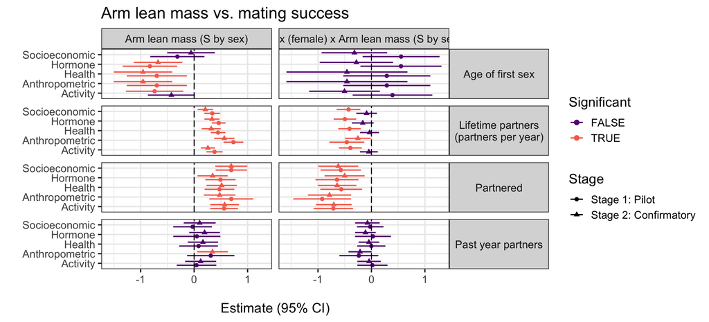

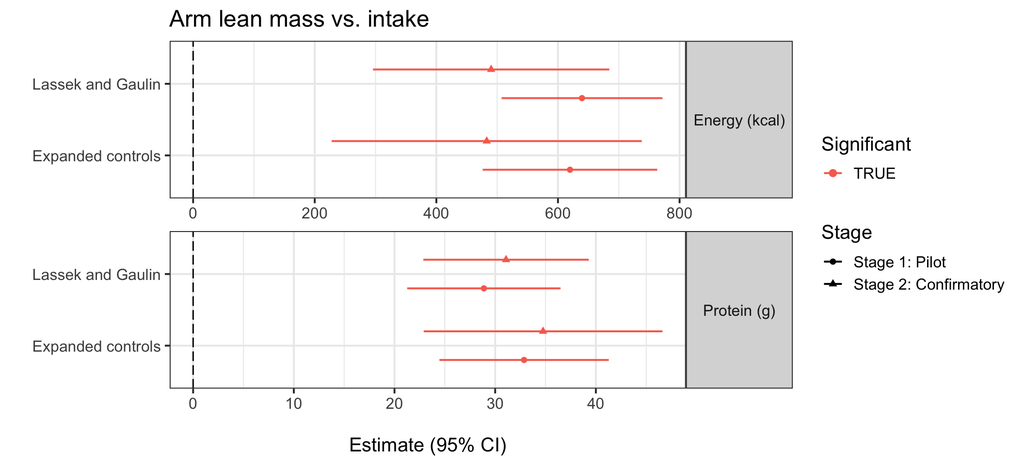

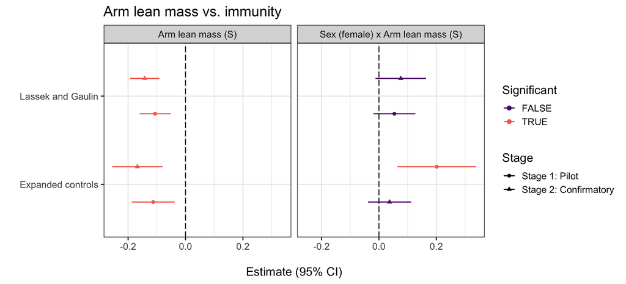

Figure S10: Coefficient plots for arm lean mass vs. mating success outcomes, energy and protein intake, and immunity (white blood cell count).

#### Leg lean mass

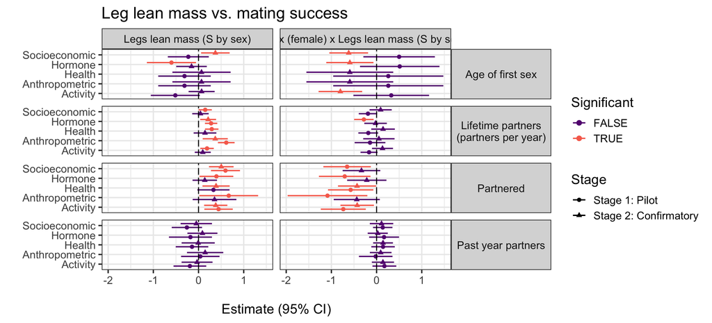

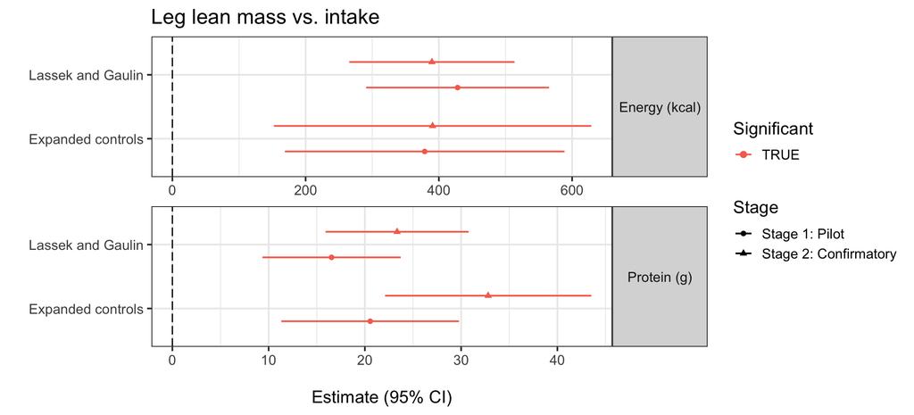

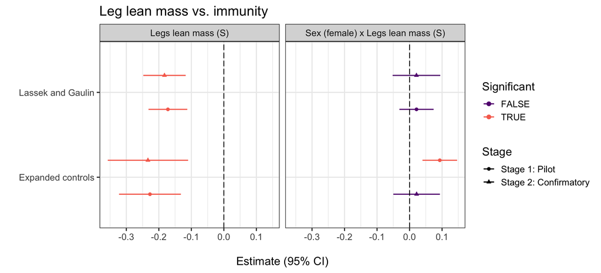

Figure S11: Coefficient plots for leg lean mass vs. mating success outcomes, energy and protein intake, and immunity (white blood cell count).

#### Trunk lean mass

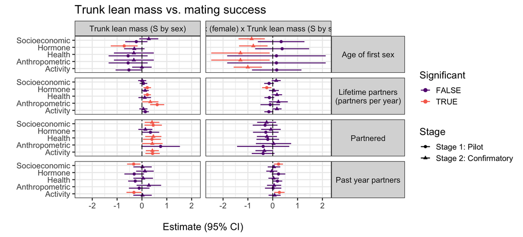

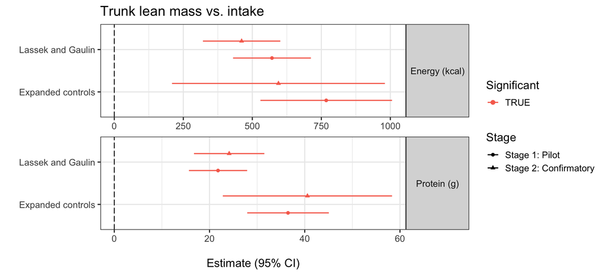

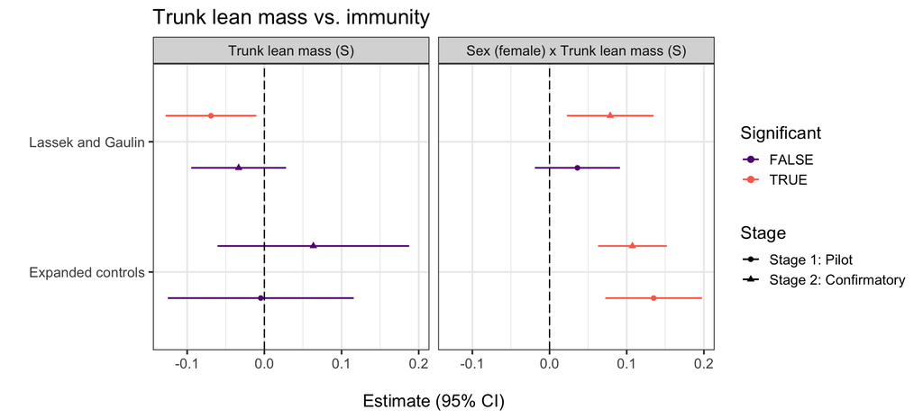

Figure S12: Coefficient plots for trunk lean mass vs. mating success outcomes, energy and protein intake, and immunity (white blood cell count).

#### Total lean mass

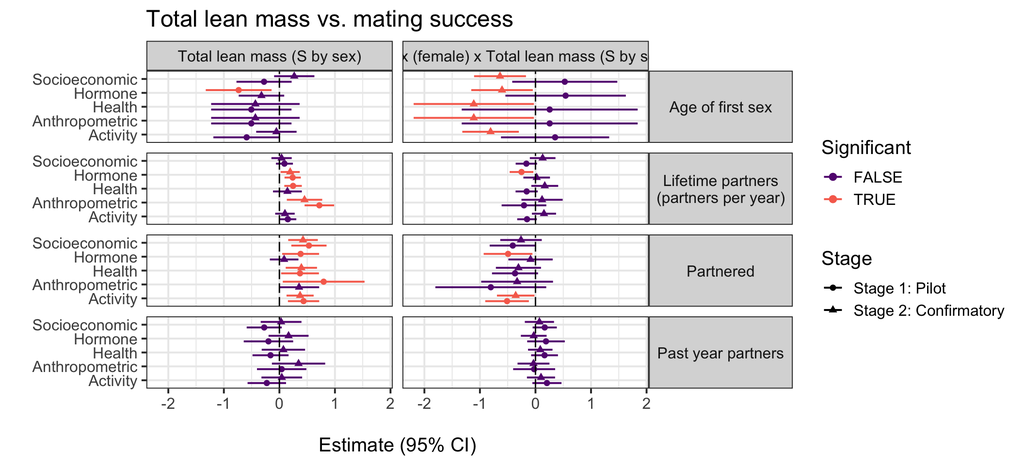

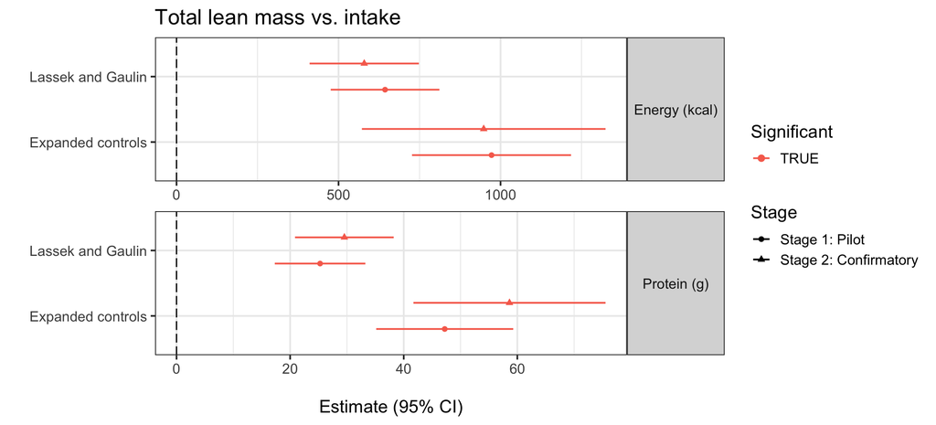

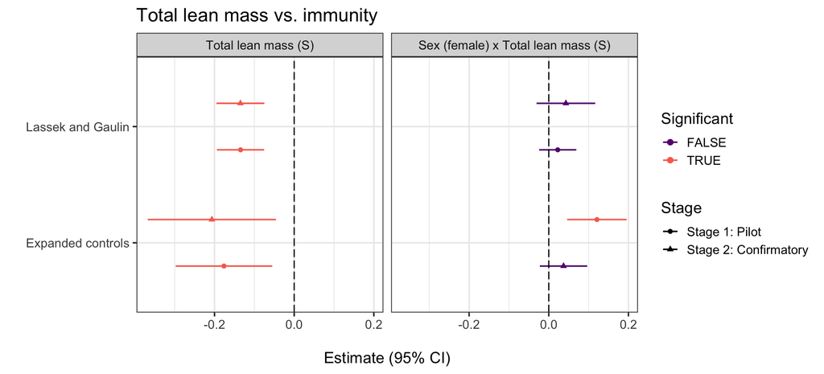

Figure S13: Coefficient plots for total lean mass vs. mating success outcomes, energy and protein intake, and immunity (white blood cell count).

### Sex-specific models

Confirmatory: At the suggestion of an anonymous reviewer, we fit all our regression models separately by sex. We plotted the grip strength coefficients for each model for each sex.

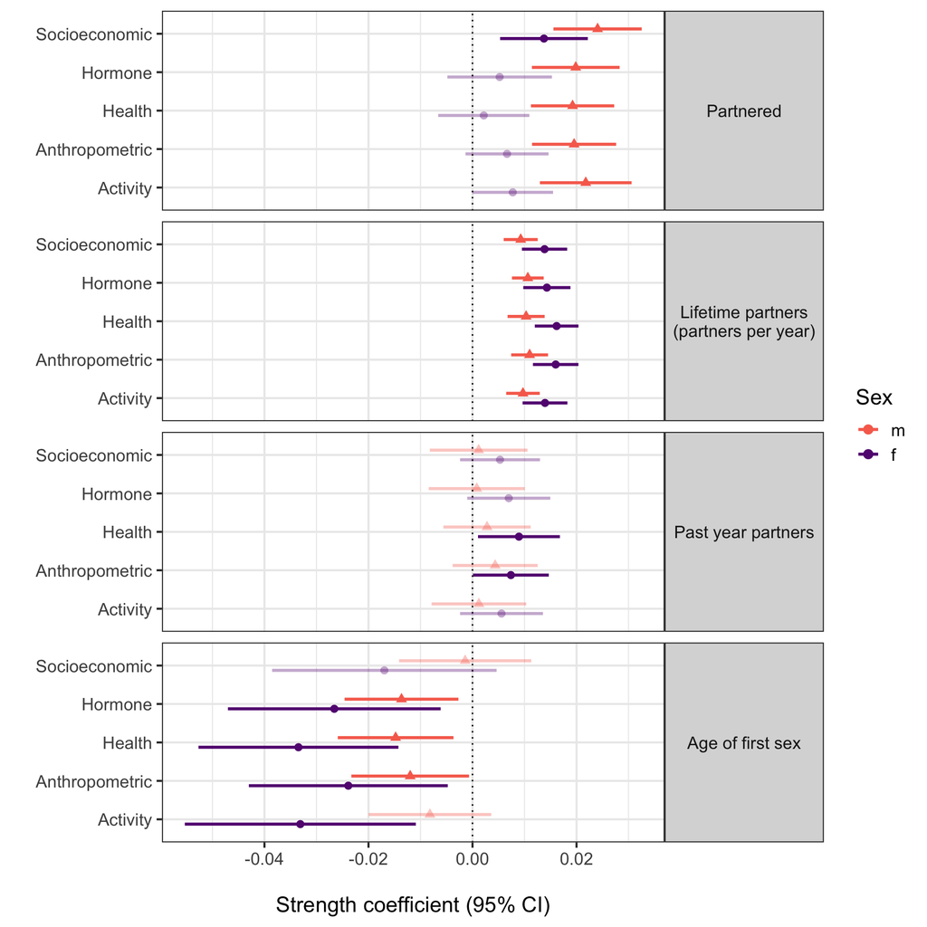

Figure S14: Confirmatory: Strength coefficients in each regression model fit separately by sex. Control variables are the same as for models fit with a $grip\ strength\times sex$ interaction term. Note that these models test if each grip strength coefficient is significantly different from 0, not if the male and female coefficients are significantly different from each other.

#### Regression tables for sex-specific models of the effect of grip strength on mating success.

|  | Anthropometric | Socioeconomic | Health | Hormone | Activity |
| --- | --- | --- | --- | --- | --- |
| (Intercept) | 18.186 | 15.366 | 18.456 | 17.956 | 17.545 |
|  | (0.978) | (0.616) | (1.050) | (0.792) | (0.735) |
| Age | 0.036 | 0.038 | 0.045 | 0.026 | 0.033 |
|  | (0.009) | (0.009) | (0.011) | (0.010) | (0.009) |
| Grip Strength | -0.024 | -0.017 | -0.033 | -0.027 | -0.033 |
|  | (0.010) | (0.011) | (0.010) | (0.010) | (0.011) |
| Partnered | 0.539 | 0.262 | 0.323 | 0.527 | 0.506 |
|  | (0.184) | (0.208) | (0.177) | (0.213) | (0.192) |
| BMI | -0.031 |  |  |  |  |
|  | (0.013) |  |  |  |  |
| Other Hispanic |  | 0.667 |  |  |  |
|  |  | (0.567) |  |  |  |
| Non-Hispanic White |  | -1.152 |  |  |  |
|  |  | (0.238) |  |  |  |
| Non-Hispanic Black |  | -1.619 |  |  |  |
|  |  | (0.321) |  |  |  |
| Non-Hispanic Asian |  | 2.284 |  |  |  |
|  |  | (0.432) |  |  |  |
| Other Race |  | -1.369 |  |  |  |
|  |  | (0.346) |  |  |  |
| Education |  | 0.616 |  |  |  |
|  |  | (0.115) |  |  |  |
| Perceived Abnormal Weight |  |  | 0.006 |  |  |
|  |  |  | (0.149) |  |  |
| White Blood Cell Count |  |  | -0.044 |  |  |
|  |  |  | (0.034) |  |  |
| Hemoglobin |  |  | 0.012 |  |  |
|  |  |  | (0.069) |  |  |
| Need special equip to walk |  |  | -0.600 |  |  |
|  |  |  | (0.594) |  |  |
| Chronic Disease Score |  |  | -0.480 |  |  |
|  |  |  | (0.119) |  |  |
| Physical Disease Count |  |  | -0.052 |  |  |
|  |  |  | (0.114) |  |  |
| Depression Score |  |  | -0.095 |  |  |
|  |  |  | (0.020) |  |  |
| Testosterone |  |  |  | -0.006 |  |
|  |  |  |  | (0.003) |  |
| Vigorous Recreation |  |  |  |  | 0.454 |
|  |  |  |  |  | (0.278) |
| Moderate Recreation |  |  |  |  | 0.581 |
|  |  |  |  |  | (0.135) |
| Vigorous Work |  |  |  |  | 0.336 |
|  |  |  |  |  | (0.284) |
| Moderate Work |  |  |  |  | -0.141 |
|  |  |  |  |  | (0.170) |
| Num.Obs. | 1626 | 1634 | 1588 | 1572 | 1634 |

Table S28: Female Age of first sex ( GAUSSIAN ) regression model coefficients

|  | Anthropometric | Socioeconomic | Health | Hormone | Activity |
| --- | --- | --- | --- | --- | --- |
| (Intercept) | 17.329 | 14.862 | 18.121 | 18.852 | 17.647 |
|  | (0.870) | (0.714) | (2.025) | (0.881) | (0.804) |
| Age | 0.007 | 0.012 | 0.015 | 0.006 | 0.004 |
|  | (0.011) | (0.011) | (0.014) | (0.011) | (0.010) |
| Grip Strength | -0.012 | -0.001 | -0.015 | -0.014 | -0.008 |
|  | (0.006) | (0.006) | (0.006) | (0.006) | (0.006) |
| Partnered | 0.832 | 0.517 | 0.648 | 0.554 | 0.835 |
|  | (0.232) | (0.246) | (0.259) | (0.246) | (0.235) |
| BMI | 0.004 |  |  |  |  |
|  | (0.013) |  |  |  |  |
| Other Hispanic |  | -0.266 |  |  |  |
|  |  | (0.258) |  |  |  |
| Non-Hispanic White |  | -0.486 |  |  |  |
|  |  | (0.200) |  |  |  |
| Non-Hispanic Black |  | -1.367 |  |  |  |
|  |  | (0.200) |  |  |  |
| Non-Hispanic Asian |  | 4.162 |  |  |  |
|  |  | (0.499) |  |  |  |
| Other Race |  | 0.152 |  |  |  |
|  |  | (0.485) |  |  |  |
| Education |  | 0.493 |  |  |  |
|  |  | (0.103) |  |  |  |
| Perceived Abnormal Weight |  |  | 0.222 |  |  |
|  |  |  | (0.267) |  |  |
| White Blood Cell Count |  |  | 0.005 |  |  |
|  |  |  | (0.039) |  |  |
| Hemoglobin |  |  | -0.031 |  |  |
|  |  |  | (0.121) |  |  |
| Need special equip to walk |  |  | 0.259 |  |  |
|  |  |  | (0.733) |  |  |
| Chronic Disease Score |  |  | -0.348 |  |  |
|  |  |  | (0.193) |  |  |
| Physical Disease Count |  |  | -0.387 |  |  |
|  |  |  | (0.202) |  |  |
| Depression Score |  |  | -0.015 |  |  |
|  |  |  | (0.041) |  |  |
| Testosterone |  |  |  | -0.002 |  |
|  |  |  |  | (0.001) |  |
| Vigorous Recreation |  |  |  |  | -0.058 |
|  |  |  |  |  | (0.189) |
| Moderate Recreation |  |  |  |  | 0.228 |
|  |  |  |  |  | (0.197) |
| Vigorous Work |  |  |  |  | -0.825 |
|  |  |  |  |  | (0.266) |
| Moderate Work |  |  |  |  | -0.588 |
|  |  |  |  |  | (0.265) |
| Num.Obs. | 1501 | 1506 | 1448 | 1447 | 1506 |

Table S29: Male Age of first sex ( GAUSSIAN ) regression model coefficients

|  | Anthropometric | Socioeconomic | Health | Hormone | Activity |
| --- | --- | --- | --- | --- | --- |
| (Intercept) | -1.892 | -2.232 | -2.241 | -1.975 | -1.968 |
|  | (0.199) | (0.175) | (0.402) | (0.148) | (0.136) |
| Grip Strength | 0.016 | 0.014 | 0.016 | 0.014 | 0.014 |
|  | (0.002) | (0.002) | (0.002) | (0.002) | (0.002) |
| Partnered | -0.549 | -0.517 | -0.517 | -0.520 | -0.511 |
|  | (0.058) | (0.063) | (0.054) | (0.062) | (0.055) |
| BMI | -0.003 |  |  |  |  |
|  | (0.005) |  |  |  |  |
| Education |  | 0.004 |  |  |  |
|  |  | (0.043) |  |  |  |
| Other Hispanic |  | 0.120 |  |  |  |
|  |  | (0.142) |  |  |  |
| Non-Hispanic White |  | 0.385 |  |  |  |
|  |  | (0.115) |  |  |  |
| Non-Hispanic Black |  | 0.434 |  |  |  |
|  |  | (0.121) |  |  |  |
| Non-Hispanic Asian |  | 0.028 |  |  |  |
|  |  | (0.172) |  |  |  |
| Other Race |  | 0.513 |  |  |  |
|  |  | (0.283) |  |  |  |
| Perceived Abnormal Weight |  |  | -0.166 |  |  |
|  |  |  | (0.066) |  |  |
| White Blood Cell Count |  |  | 0.042 |  |  |
|  |  |  | (0.009) |  |  |
| Hemoglobin |  |  | -0.002 |  |  |
|  |  |  | (0.035) |  |  |
| Need special equip to walk |  |  | -0.327 |  |  |
|  |  |  | (0.154) |  |  |
| Chronic Disease Score |  |  | -0.108 |  |  |
|  |  |  | (0.057) |  |  |
| Physical Disease Count |  |  | 0.004 |  |  |
|  |  |  | (0.049) |  |  |
| Depression Score |  |  | 0.032 |  |  |
|  |  |  | (0.007) |  |  |
| Testosterone |  |  |  | 0.003 |  |
|  |  |  |  | (0.001) |  |
| Vigorous Recreation |  |  |  |  | 0.090 |
|  |  |  |  |  | (0.092) |
| Moderate Recreation |  |  |  |  | -0.087 |
|  |  |  |  |  | (0.092) |
| Vigorous Work |  |  |  |  | 0.141 |
|  |  |  |  |  | (0.134) |
| Moderate Work |  |  |  |  | 0.229 |
|  |  |  |  |  | (0.075) |
| Num.Obs. | 1673 | 1681 | 1633 | 1617 | 1681 |

Table S30: Female Lifetime partners (partners per year) ( QUASIPOISSON ) regression model coefficients

|  | Anthropometric | Socioeconomic | Health | Hormone | Activity |
| --- | --- | --- | --- | --- | --- |
| (Intercept) | -1.307 | -1.362 | -1.460 | -1.907 | -1.458 |
|  | (0.218) | (0.212) | (0.391) | (0.184) | (0.184) |
| Grip Strength | 0.011 | 0.009 | 0.010 | 0.011 | 0.010 |
|  | (0.002) | (0.002) | (0.002) | (0.002) | (0.002) |
| Partnered | -0.492 | -0.436 | -0.478 | -0.434 | -0.476 |
|  | (0.078) | (0.075) | (0.066) | (0.072) | (0.073) |
| BMI | -0.009 |  |  |  |  |
|  | (0.006) |  |  |  |  |
| Education |  | -0.034 |  |  |  |
|  |  | (0.032) |  |  |  |
| Other Hispanic |  | 0.236 |  |  |  |
|  |  | (0.139) |  |  |  |
| Non-Hispanic White |  | 0.009 |  |  |  |
|  |  | (0.124) |  |  |  |
| Non-Hispanic Black |  | 0.355 |  |  |  |
|  |  | (0.114) |  |  |  |
| Non-Hispanic Asian |  | -0.686 |  |  |  |
|  |  | (0.167) |  |  |  |
| Other Race |  | 0.253 |  |  |  |
|  |  | (0.169) |  |  |  |
| Perceived Abnormal Weight |  |  | -0.090 |  |  |
|  |  |  | (0.100) |  |  |
| White Blood Cell Count |  |  | -0.004 |  |  |
|  |  |  | (0.018) |  |  |
| Hemoglobin |  |  | 0.001 |  |  |
|  |  |  | (0.025) |  |  |
| Need special equip to walk |  |  | 0.163 |  |  |
|  |  |  | (0.271) |  |  |
| Chronic Disease Score |  |  | -0.076 |  |  |
|  |  |  | (0.058) |  |  |
| Physical Disease Count |  |  | -0.013 |  |  |
|  |  |  | (0.052) |  |  |
| Depression Score |  |  | 0.019 |  |  |
|  |  |  | (0.007) |  |  |
| Testosterone |  |  |  | 0.001 |  |
|  |  |  |  | (0.000) |  |
| Vigorous Recreation |  |  |  |  | 0.280 |
|  |  |  |  |  | (0.115) |
| Moderate Recreation |  |  |  |  | -0.230 |
|  |  |  |  |  | (0.070) |
| Vigorous Work |  |  |  |  | 0.023 |
|  |  |  |  |  | (0.098) |
| Moderate Work |  |  |  |  | 0.022 |
|  |  |  |  |  | (0.094) |
| Num.Obs. | 1558 | 1563 | 1504 | 1503 | 1563 |

Table S31: Male Lifetime partners (partners per year) ( QUASIPOISSON ) regression model coefficients

|  | Anthropometric | Socioeconomic | Health | Hormone | Activity |
| --- | --- | --- | --- | --- | --- |
| (Intercept) | -0.277 | -0.994 | 0.274 | -0.276 | -0.456 |
|  | (0.414) | (0.509) | (0.954) | (0.393) | (0.378) |
| Lifetime sex partners (S) | -0.482 | -0.458 | -0.452 | -0.481 | -0.464 |
|  | (0.076) | (0.086) | (0.076) | (0.081) | (0.076) |
| Age | 0.022 | 0.023 | 0.029 | 0.020 | 0.021 |
|  | (0.006) | (0.006) | (0.006) | (0.006) | (0.006) |
| Grip Strength | 0.007 | 0.014 | 0.002 | 0.005 | 0.008 |
|  | (0.004) | (0.004) | (0.004) | (0.005) | (0.004) |
| BMI | -0.007 |  |  |  |  |
|  | (0.007) |  |  |  |  |
| Education |  | 0.075 |  |  |  |
|  |  | (0.068) |  |  |  |
| Other Hispanic |  | -0.068 |  |  |  |
|  |  | (0.192) |  |  |  |
| Non-Hispanic White |  | -0.050 |  |  |  |
|  |  | (0.218) |  |  |  |
| Non-Hispanic Black |  | -1.338 |  |  |  |
|  |  | (0.205) |  |  |  |
| Non-Hispanic Asian |  | 0.190 |  |  |  |
|  |  | (0.239) |  |  |  |
| Other Race |  | -0.435 |  |  |  |
|  |  | (0.493) |  |  |  |
| Perceived Abnormal Weight |  |  | 0.037 |  |  |
|  |  |  | (0.106) |  |  |
| White Blood Cell Count |  |  | 0.015 |  |  |
|  |  |  | (0.021) |  |  |
| Hemoglobin |  |  | -0.051 |  |  |
|  |  |  | (0.058) |  |  |
| Need special equip to walk |  |  | -0.590 |  |  |
|  |  |  | (0.223) |  |  |
| Chronic Disease Score |  |  | -0.238 |  |  |
|  |  |  | (0.118) |  |  |
| Physical Disease Count |  |  | -0.004 |  |  |
|  |  |  | (0.111) |  |  |
| Depression Score |  |  | -0.016 |  |  |
|  |  |  | (0.018) |  |  |
| Testosterone |  |  |  | -0.001 |  |
|  |  |  |  | (0.002) |  |
| Vigorous Recreation |  |  |  |  | 0.034 |
|  |  |  |  |  | (0.146) |
| Moderate Recreation |  |  |  |  | 0.180 |
|  |  |  |  |  | (0.120) |
| Vigorous Work |  |  |  |  | -0.265 |
|  |  |  |  |  | (0.145) |
| Moderate Work |  |  |  |  | -0.236 |
|  |  |  |  |  | (0.167) |
| Num.Obs. | 1673 | 1681 | 1633 | 1617 | 1681 |

Table S32: Female Partnered ( QUASIBINOMIAL ) regression model coefficients

|  | Anthropometric | Socioeconomic | Health | Hormone | Activity |
| --- | --- | --- | --- | --- | --- |
| (Intercept) | -4.030 | -4.048 | -2.597 | -2.505 | -3.842 |
|  | (0.632) | (0.518) | (1.287) | (0.506) | (0.513) |
| Lifetime sex partners (S) | -0.186 | -0.159 | -0.175 | -0.154 | -0.192 |
|  | (0.050) | (0.048) | (0.045) | (0.046) | (0.049) |
| Age | 0.068 | 0.070 | 0.074 | 0.068 | 0.070 |
|  | (0.006) | (0.007) | (0.007) | (0.007) | (0.006) |
| Grip Strength | 0.020 | 0.024 | 0.019 | 0.020 | 0.022 |
|  | (0.004) | (0.004) | (0.004) | (0.004) | (0.004) |
| BMI | 0.014 |  |  |  |  |
|  | (0.011) |  |  |  |  |
| Education |  | 0.067 |  |  |  |
|  |  | (0.068) |  |  |  |
| Other Hispanic |  | -0.070 |  |  |  |
|  |  | (0.354) |  |  |  |
| Non-Hispanic White |  | -0.358 |  |  |  |
|  |  | (0.270) |  |  |  |
| Non-Hispanic Black |  | -1.122 |  |  |  |
|  |  | (0.261) |  |  |  |
| Non-Hispanic Asian |  | 0.091 |  |  |  |
|  |  | (0.247) |  |  |  |
| Other Race |  | -0.661 |  |  |  |
|  |  | (0.354) |  |  |  |
| Perceived Abnormal Weight |  |  | -0.003 |  |  |
|  |  |  | (0.096) |  |  |
| White Blood Cell Count |  |  | 0.015 |  |  |
|  |  |  | (0.031) |  |  |
| Hemoglobin |  |  | -0.073 |  |  |
|  |  |  | (0.069) |  |  |
| Need special equip to walk |  |  | -0.656 |  |  |
|  |  |  | (0.398) |  |  |
| Chronic Disease Score |  |  | -0.022 |  |  |
|  |  |  | (0.127) |  |  |
| Physical Disease Count |  |  | -0.154 |  |  |
|  |  |  | (0.067) |  |  |
| Depression Score |  |  | -0.064 |  |  |
|  |  |  | (0.022) |  |  |
| Testosterone |  |  |  | -0.003 |  |
|  |  |  |  | (0.000) |  |
| Vigorous Recreation |  |  |  |  | 0.042 |
|  |  |  |  |  | (0.167) |
| Moderate Recreation |  |  |  |  | -0.165 |
|  |  |  |  |  | (0.174) |
| Vigorous Work |  |  |  |  | 0.176 |
|  |  |  |  |  | (0.161) |
| Moderate Work |  |  |  |  | -0.117 |
|  |  |  |  |  | (0.073) |
| Num.Obs. | 1558 | 1563 | 1504 | 1503 | 1563 |

Table S33: Male Partnered ( QUASIBINOMIAL ) regression model coefficients

|  | Anthropometric | Socioeconomic | Health | Hormone | Activity |
| --- | --- | --- | --- | --- | --- |
| (Intercept) | -0.251 | -0.334 | -0.441 | -0.345 | -0.310 |
|  | (0.277) | (0.272) | (0.565) | (0.265) | (0.253) |
| Age (S) | -0.442 | -0.467 | -0.429 | -0.444 | -0.434 |
|  | (0.069) | (0.069) | (0.055) | (0.078) | (0.068) |
| Grip Strength | 0.007 | 0.005 | 0.009 | 0.007 | 0.006 |
|  | (0.004) | (0.004) | (0.004) | (0.004) | (0.004) |
| Partnered | 0.275 | 0.270 | 0.374 | 0.276 | 0.299 |
|  | (0.265) | (0.255) | (0.272) | (0.286) | (0.278) |
| BMI | -0.003 |  |  |  |  |
|  | (0.003) |  |  |  |  |
| strength:partneredTRUE | -0.006 | -0.006 | -0.007 | -0.006 | -0.006 |
|  | (0.004) | (0.004) | (0.004) | (0.004) | (0.004) |
| Education |  | -0.024 |  |  |  |
|  |  | (0.032) |  |  |  |
| Other Hispanic |  | 0.102 |  |  |  |
|  |  | (0.057) |  |  |  |
| Non-Hispanic White |  | 0.209 |  |  |  |
|  |  | (0.033) |  |  |  |
| Non-Hispanic Black |  | 0.320 |  |  |  |
|  |  | (0.075) |  |  |  |
| Non-Hispanic Asian |  | 0.117 |  |  |  |
|  |  | (0.084) |  |  |  |
| Other Race |  | 0.173 |  |  |  |
|  |  | (0.083) |  |  |  |
| Perceived Abnormal Weight |  |  | -0.082 |  |  |
|  |  |  | (0.059) |  |  |
| White Blood Cell Count |  |  | 0.001 |  |  |
|  |  |  | (0.011) |  |  |
| Hemoglobin |  |  | 0.000 |  |  |
|  |  |  | (0.024) |  |  |
| Need special equip to walk |  |  | -0.033 |  |  |
|  |  |  | (0.259) |  |  |
| Chronic Disease Score |  |  | -0.025 |  |  |
|  |  |  | (0.023) |  |  |
| Physical Disease Count |  |  | -0.005 |  |  |
|  |  |  | (0.058) |  |  |
| Depression Score |  |  | 0.013 |  |  |
|  |  |  | (0.005) |  |  |
| Testosterone |  |  |  | 0.001 |  |
|  |  |  |  | (0.001) |  |
| Vigorous Recreation |  |  |  |  | 0.113 |
|  |  |  |  |  | (0.086) |
| Moderate Recreation |  |  |  |  | -0.004 |
|  |  |  |  |  | (0.065) |
| Vigorous Work |  |  |  |  | 0.206 |
|  |  |  |  |  | (0.122) |
| Moderate Work |  |  |  |  | 0.028 |
|  |  |  |  |  | (0.043) |
| Num.Obs. | 1631 | 1639 | 1590 | 1575 | 1639 |

Table S34: Female Past year partners ( QUASIPOISSON ) regression model coefficients

|  | Anthropometric | Socioeconomic | Health | Hormone | Activity |
| --- | --- | --- | --- | --- | --- |
| (Intercept) | 0.472 | 0.583 | 0.082 | 0.083 | 0.434 |
|  | (0.508) | (0.527) | (0.520) | (0.439) | (0.490) |
| Age (S) | -0.216 | -0.232 | -0.231 | -0.185 | -0.211 |
|  | (0.056) | (0.068) | (0.087) | (0.064) | (0.072) |
| Grip Strength | 0.004 | 0.001 | 0.003 | 0.001 | 0.001 |
|  | (0.004) | (0.005) | (0.004) | (0.005) | (0.005) |
| Partnered | -0.389 | -0.497 | -0.517 | -0.673 | -0.595 |
|  | (0.487) | (0.538) | (0.515) | (0.535) | (0.525) |
| BMI | -0.011 |  |  |  |  |
|  | (0.006) |  |  |  |  |
| strength:partneredTRUE | 0.000 | 0.001 | 0.001 | 0.003 | 0.002 |
|  | (0.005) | (0.005) | (0.005) | (0.005) | (0.005) |
| Education |  | -0.065 |  |  |  |
|  |  | (0.028) |  |  |  |
| Other Hispanic |  | 0.012 |  |  |  |
|  |  | (0.129) |  |  |  |
| Non-Hispanic White |  | 0.118 |  |  |  |
|  |  | (0.129) |  |  |  |
| Non-Hispanic Black |  | 0.295 |  |  |  |
|  |  | (0.086) |  |  |  |
| Non-Hispanic Asian |  | -0.094 |  |  |  |
|  |  | (0.082) |  |  |  |
| Other Race |  | 0.242 |  |  |  |
|  |  | (0.168) |  |  |  |
| Perceived Abnormal Weight |  |  | -0.091 |  |  |
|  |  |  | (0.074) |  |  |
| White Blood Cell Count |  |  | 0.015 |  |  |
|  |  |  | (0.018) |  |  |
| Hemoglobin |  |  | 0.004 |  |  |
|  |  |  | (0.024) |  |  |
| Need special equip to walk |  |  | 0.028 |  |  |
|  |  |  | (0.223) |  |  |
| Chronic Disease Score |  |  | 0.139 |  |  |
|  |  |  | (0.071) |  |  |
| Physical Disease Count |  |  | -0.016 |  |  |
|  |  |  | (0.090) |  |  |
| Depression Score |  |  | 0.025 |  |  |
|  |  |  | (0.018) |  |  |
| Testosterone |  |  |  | 0.001 |  |
|  |  |  |  | (0.000) |  |
| Vigorous Recreation |  |  |  |  | 0.025 |
|  |  |  |  |  | (0.096) |
| Moderate Recreation |  |  |  |  | -0.039 |
|  |  |  |  |  | (0.057) |
| Vigorous Work |  |  |  |  | 0.113 |
|  |  |  |  |  | (0.037) |
| Moderate Work |  |  |  |  | 0.023 |
|  |  |  |  |  | (0.107) |
| Num.Obs. | 1525 | 1530 | 1470 | 1469 | 1530 |

Table S35: Male Past year partners ( QUASIPOISSON ) regression model coefficients